# 采用贝叶斯序列分析确定样本量

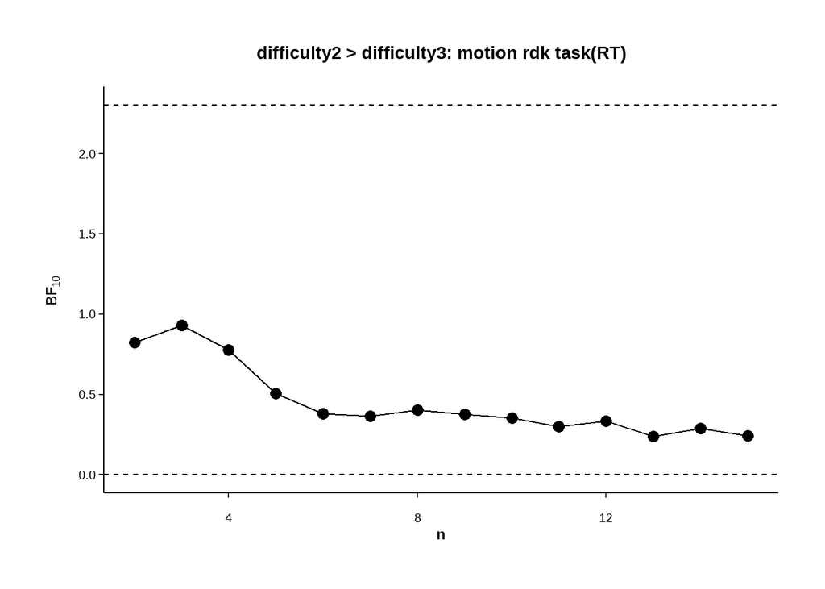

```r
plot_bfs_2vs3 <-
  plot_ttest(bfs_int_diff_mr_rt, '2 vs 3', 'difficulty2 > difficulty3: motion rdk task(RT)')
plot_bfs_2vs3
```

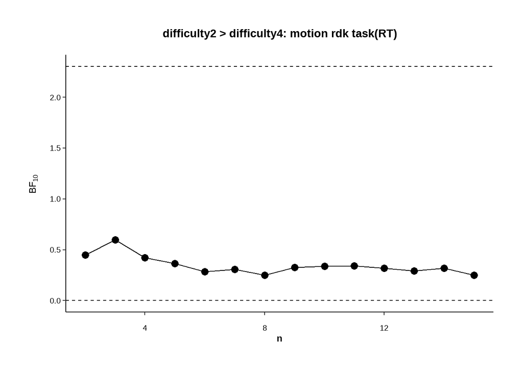

```r
plot_bfs_2vs4 <-
  plot_ttest(bfs_int_diff_mr_rt, '2 vs 4', 'difficulty2 > difficulty4: motion rdk task(RT)')
plot_bfs_2vs4
```

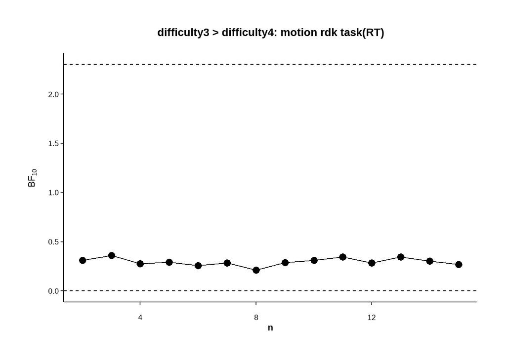

```r
plot_bfs_3vs4 <-
  plot_ttest(bfs_int_diff_mr_rt, '3 vs 4', 'difficulty3 > difficulty4: motion rdk task(RT)')
plot_bfs_3vs4
```

**查看数据的变化趋势**

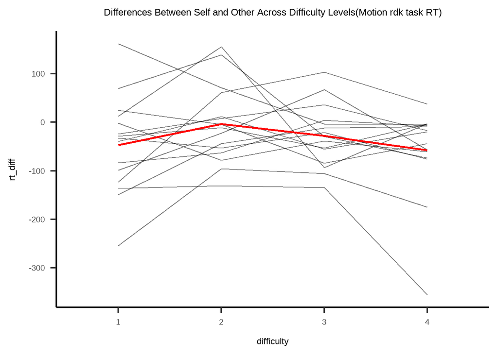

```r
ggplot(df_motion_diff_rdk_long, aes(x = difficulty, y = rt_diff, group = subj_idx)) +
  geom_line(alpha = 0.5) +
  stat_summary(aes(group = 1), fun = mean, geom = "line", color = "red", size = 1) + labs(title = "Differences Between Self and Other Across Difficulty Levels(Motion rdk task RT)") +
  papaja::theme_apa(base_size = 18,# base_family = "Times"
                    )
```

#### 0.3.1.3 任务间比较

##### 0.3.1.3.1 ACC

```r
bfs_task_diff_acc <- bf_aov(data_motion_diff, 'acc_diff_so', 'part')
```

[output not shown]

[output cut: 15 more lines]

[output not shown]

```
## # A tibble: 15 × 3
##    bfs_a bfs_diff bfs_int
##    <dbl>    <dbl>   <dbl>
##  1 1        1       1
##  2 0.509    0.720   0.205
##  3 0.518    0.731   0.197
##  4 0.496    0.728   0.205
##  5 0.512    0.697   0.204
##  6 0.506    0.712   0.202
##  7 0.535    0.748   0.192
##  8 0.519    0.719   0.201
##  9 0.526    0.732   0.196
## 10 0.520    0.738   0.210
## 11 0.516    0.718   0.203
## 12 0.520    0.734   0.202
## 13 0.510    0.722   0.201
## 14 0.520    0.718   0.202
## 15 0.519    0.730   0.195
```

```r
bfs_task_diff_acc
```

```
## # A tibble: 15 × 3
##    bfs_a bfs_diff bfs_int
##    <dbl>    <dbl>   <dbl>
##  1 1        1       1
##  2 0.509    0.720   0.205
##  3 0.518    0.731   0.197
##  4 0.496    0.728   0.205
##  5 0.512    0.697   0.204
##  6 0.506    0.712   0.202
##  7 0.535    0.748   0.192
##  8 0.519    0.719   0.201
##  9 0.526    0.732   0.196
## 10 0.520    0.738   0.210
## 11 0.516    0.718   0.203
## 12 0.520    0.734   0.202
## 13 0.510    0.722   0.201
## 14 0.520    0.718   0.202
## 15 0.519    0.730   0.195
```

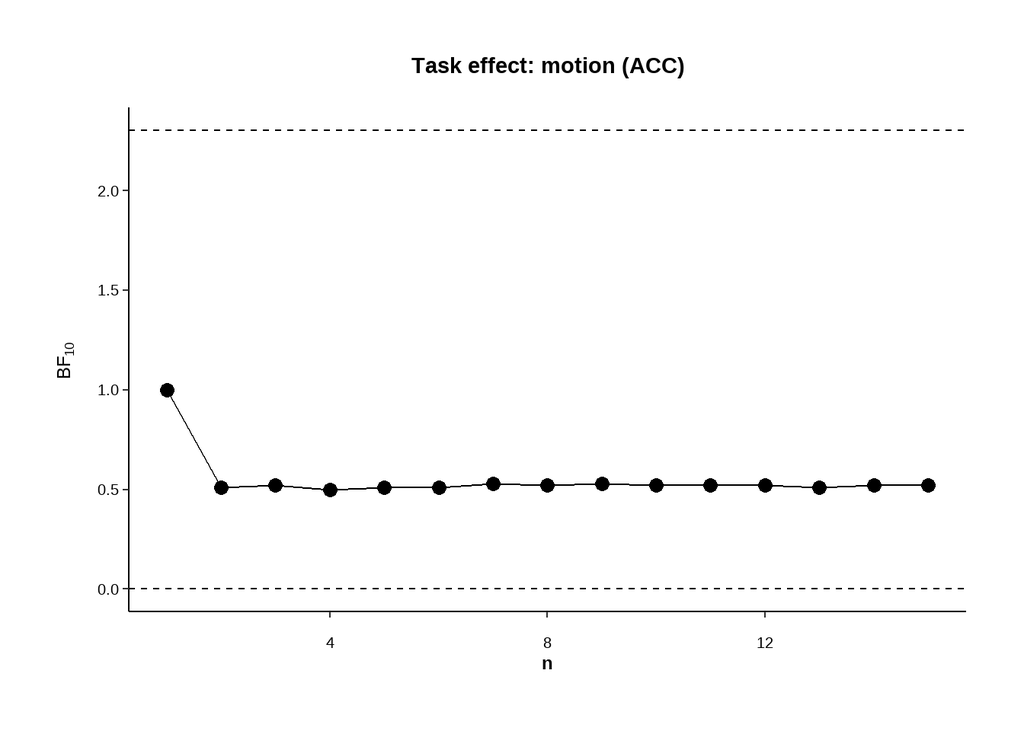

```r
plot_bfs_task <- plot_aov(bfs_task_diff_acc , 'bfs_a', 'Task effect: motion (ACC)')
plot_bfs_task
```

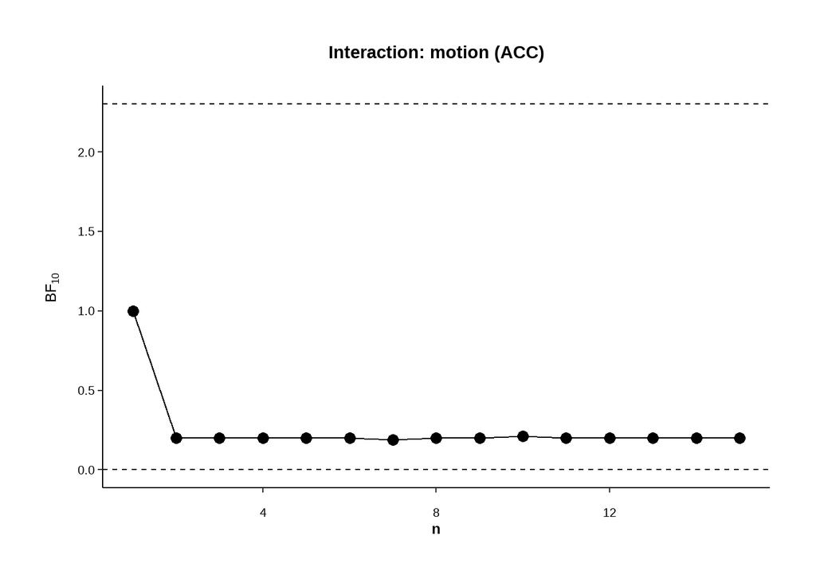

```r
plot_bfs_task_int <- plot_aov(bfs_task_diff_acc , 'bfs_int', 'Interaction: motion (ACC)')
plot_bfs_task_int
```

##### 0.3.1.3.2 RT

```r
bfs_task_diff_rt <- bf_aov(data_motion_diff, 'rt_diff_os', 'part')
```

[output not shown]

[output cut: 15 more lines]

[output not shown]

```
## # A tibble: 15 × 3
##    bfs_a bfs_diff bfs_int
##    <dbl>    <dbl>   <dbl>
##  1 1        1       1
##  2 0.769    0.120   0.625
##  3 0.774    0.122   0.609
##  4 0.739    0.122   0.623
##  5 0.775    0.117   0.634
##  6 0.755    0.116   0.621
##  7 0.805    0.125   0.590
##  8 0.779    0.120   0.617
##  9 0.791    0.123   0.602
## 10 0.788    0.124   0.638
## 11 0.787    0.121   0.613
## 12 0.797    0.125   0.614
## 13 0.767    0.120   0.617
## 14 0.783    0.121   0.616
## 15 0.785    0.122   0.596
```

```r
bfs_task_diff_rt
```

```
## # A tibble: 15 × 3
##    bfs_a bfs_diff bfs_int
##    <dbl>    <dbl>   <dbl>
##  1 1        1       1
##  2 0.769    0.120   0.625
##  3 0.774    0.122   0.609
##  4 0.739    0.122   0.623
##  5 0.775    0.117   0.634
##  6 0.755    0.116   0.621
##  7 0.805    0.125   0.590
##  8 0.779    0.120   0.617
##  9 0.791    0.123   0.602
## 10 0.788    0.124   0.638
## 11 0.787    0.121   0.613
## 12 0.797    0.125   0.614
## 13 0.767    0.120   0.617
## 14 0.783    0.121   0.616
## 15 0.785    0.122   0.596
```

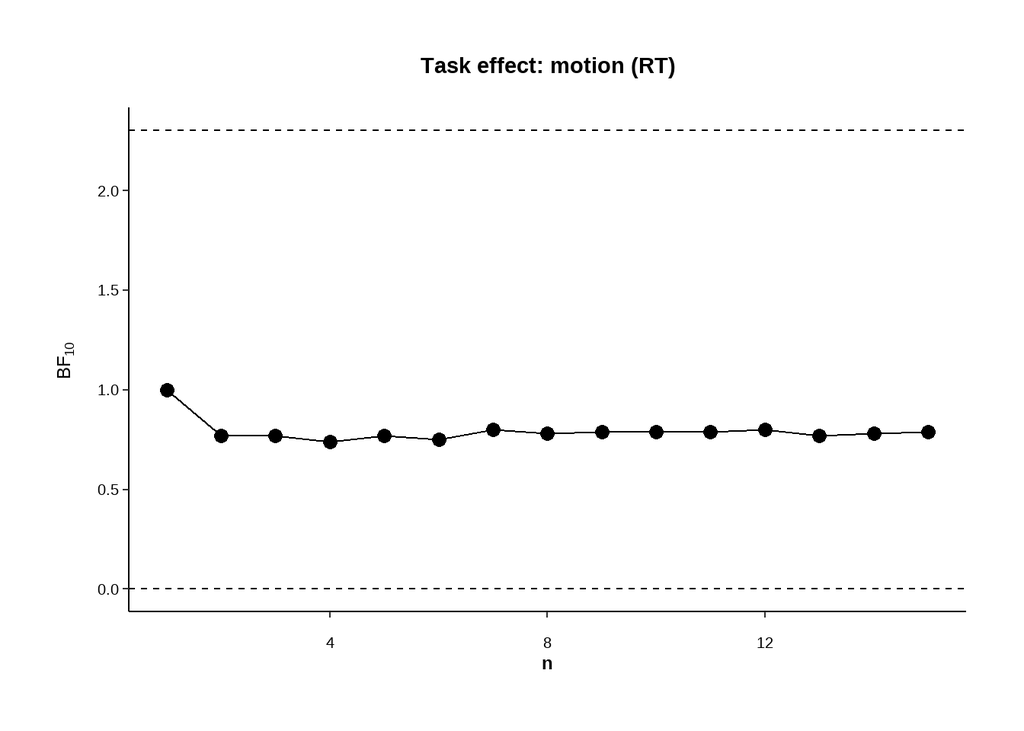

```r
plot_bfs_task <- plot_aov(bfs_task_diff_rt , 'bfs_a', 'Task effect: motion (RT)')
plot_bfs_task
```

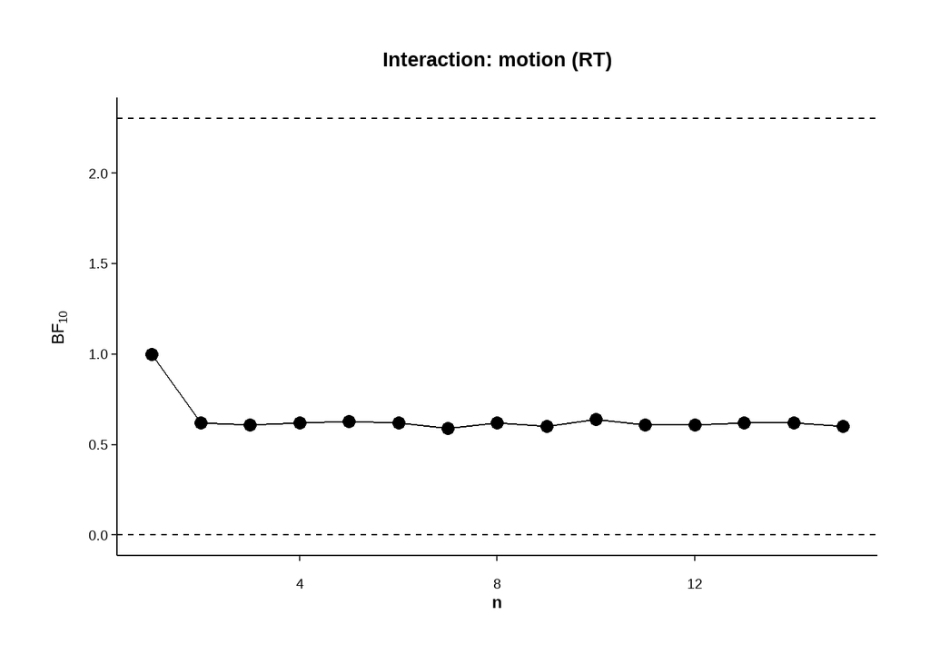

```r
plot_bfs_task_int <- plot_aov(bfs_task_diff_rt , 'bfs_int', 'Interaction: motion (RT)')
plot_bfs_task_int
```

### 0.3.2 颜色组

**先检查是否存在匹配类型与关联类型的交互作用**

ACC

```r
set.seed(1234)

# 零模型
null_model <- BayesFactor::lmBF(
  acc ~ 1 + subj_idx + isMatch:subj_idx + association:subj_idx,
  data = df_color_match,
  whichRandom = "subj_idx",
  rscaleFixed = 0.5,
  rscaleRandom = 1,
  iteration = 10000)
# 仅包含 match 主效应
model_match <- BayesFactor::lmBF(
  acc ~ isMatch + subj_idx + isMatch:subj_idx + association:subj_idx,
  data = df_color_match,
  whichRandom = "subj_idx",
  rscaleFixed = 0.5,
  rscaleRandom = 1,
  iteration = 10000)
# 仅包含 association 主效应
model_association <- BayesFactor::lmBF(
  acc ~ association + subj_idx + isMatch:subj_idx + association:subj_idx,
  data = df_color_match,
  whichRandom = "subj_idx",
  rscaleFixed = 0.5,
  rscaleRandom = 1,
  iteration = 10000)
# 包含两个主效应（match + association）
model_main <- BayesFactor::lmBF(
  acc ~ isMatch + association + subj_idx + isMatch:subj_idx + association:subj_idx,
  data = df_color_match,
  whichRandom = "subj_idx",
  rscaleFixed = 0.5,
  rscaleRandom = 1,
  iteration = 10000)
# 包含主效应和交互作用（isMatch * association）
model_int <- BayesFactor::lmBF(
  acc ~ isMatch * association + subj_idx + isMatch:subj_idx + association:subj_idx,
  data = df_color_match,
  whichRandom = "subj_idx",
  rscaleFixed = 0.5,
  rscaleRandom = 1,
  iteration = 10000)
# 计算BF值
bf_int <- model_int / model_main
bf_ass <- model_main / model_match
bf_match <- model_main / model_association

print(bf_int)
```

```
## Bayes factor analysis
## --------------
## [1] isMatch * association + subj_idx + isMatch:subj_idx + association:subj_idx : 0.2512638 ±2.52%
##
## Against denominator:
##   acc ~ isMatch + association + subj_idx + isMatch:subj_idx + association:subj_idx
## ---
## Bayes factor type: BFlinearModel, JZS
```

```r
print(bf_ass)
```

```
## Bayes factor analysis
## --------------
## [1] isMatch + association + subj_idx + isMatch:subj_idx + association:subj_idx : 0.3820594 ±1.75%
##
## Against denominator:
##   acc ~ isMatch + subj_idx + isMatch:subj_idx + association:subj_idx
## ---
## Bayes factor type: BFlinearModel, JZS
```

```r
print(bf_match)
```

```
## Bayes factor analysis
## --------------
## [1] isMatch + association + subj_idx + isMatch:subj_idx + association:subj_idx : 0.2702622 ±1.64%
##
## Against denominator:
##   acc ~ association + subj_idx + isMatch:subj_idx + association:subj_idx
## ---
## Bayes factor type: BFlinearModel, JZS
```

RT

```r
set.seed(1234)

# 零模型
null_model <- BayesFactor::lmBF(
  rt ~ 1 + subj_idx + isMatch:subj_idx + association:subj_idx,
  data = df_color_match,
  whichRandom = "subj_idx",
  rscaleFixed = 0.5,
  rscaleRandom = 1,
  iteration = 10000)
# 仅包含 match 主效应
model_match <- BayesFactor::lmBF(
  rt ~ isMatch + subj_idx + isMatch:subj_idx + association:subj_idx,
  data = df_color_match,
  whichRandom = "subj_idx",
  rscaleFixed = 0.5,
  rscaleRandom = 1,
  iteration = 10000)
# 仅包含 association 主效应
model_association <- BayesFactor::lmBF(
  rt ~ association + subj_idx + isMatch:subj_idx + association:subj_idx,
  data = df_color_match,
  whichRandom = "subj_idx",
  rscaleFixed = 0.5,
  rscaleRandom = 1,
  iteration = 10000)
# 包含两个主效应（match + association）
model_main <- BayesFactor::lmBF(
  rt ~ isMatch + association + subj_idx + isMatch:subj_idx + association:subj_idx,
  data = df_color_match,
  whichRandom = "subj_idx",
  rscaleFixed = 0.5,
  rscaleRandom = 1,
  iteration = 10000)
# 包含主效应和交互作用（isMatch * association）
model_int <- BayesFactor::lmBF(
  rt ~ isMatch + association + isMatch : association + subj_idx + isMatch:subj_idx + association:subj_idx,
  data = df_color_match,
  whichRandom = "subj_idx",
  rscaleFixed = 0.5,
  rscaleRandom = 1,
  iteration = 10000)
# 计算BF值
bf_int <- model_int / model_main
bf_ass <- model_main / model_match
bf_match <- model_main / model_association

print(bf_int)
```

```
## Bayes factor analysis
## --------------
## [1] isMatch + association + isMatch:association + subj_idx + isMatch:subj_idx + association:subj_idx : 9.083818 ±2.61%
##
## Against denominator:
##   rt ~ isMatch + association + subj_idx + isMatch:subj_idx + association:subj_idx
## ---
## Bayes factor type: BFlinearModel, JZS
```

```r
print(bf_ass)
```

```
## Bayes factor analysis
## --------------
## [1] isMatch + association + subj_idx + isMatch:subj_idx + association:subj_idx : 0.28017 ±1.88%
##
## Against denominator:
##   rt ~ isMatch + subj_idx + isMatch:subj_idx + association:subj_idx
## ---
## Bayes factor type: BFlinearModel, JZS
```

```r
print(bf_match)
```

```
## Bayes factor analysis
## --------------
## [1] isMatch + association + subj_idx + isMatch:subj_idx + association:subj_idx : 0.5421983 ±1.79%
##
## Against denominator:
##   rt ~ association + subj_idx + isMatch:subj_idx + association:subj_idx
## ---
## Bayes factor type: BFlinearModel, JZS
```

#### 0.3.2.1 匹配任务

##### 0.3.2.1.1 关联类型主效应

###### 0.3.2.1.1.1 ACC

```r
bfs_association_cm_acc <- bf_aov(df_color_match, 'acc', 'association')
```

[output not shown]

```
## # A tibble: 10 × 3
##    bfs_a      bfs_diff bfs_int
##    <dbl>         <dbl>   <dbl>
##  1 1                1    1
##  2 0.543 141639988487.   0.186
##  3 0.561 148147279074.   0.173
##  4 0.514 141655591812.   0.188
##  5 0.540 138623928472.   0.184
##  6 0.534 141918967295.   0.181
##  7 0.558 146800938366.   0.176
##  8 0.549 141725302796.   0.181
##  9 0.549 142426352079.   0.180
## 10 0.545 142141901966.   0.192
```

```r
bfs_association_cm_acc
```

```
## # A tibble: 10 × 3
##    bfs_a      bfs_diff bfs_int
##    <dbl>         <dbl>   <dbl>
##  1 1                1    1
##  2 0.543 141639988487.   0.186
##  3 0.561 148147279074.   0.173
##  4 0.514 141655591812.   0.188
##  5 0.540 138623928472.   0.184
##  6 0.534 141918967295.   0.181
##  7 0.558 146800938366.   0.176
##  8 0.549 141725302796.   0.181
##  9 0.549 142426352079.   0.180
## 10 0.545 142141901966.   0.192
```

**可视化**

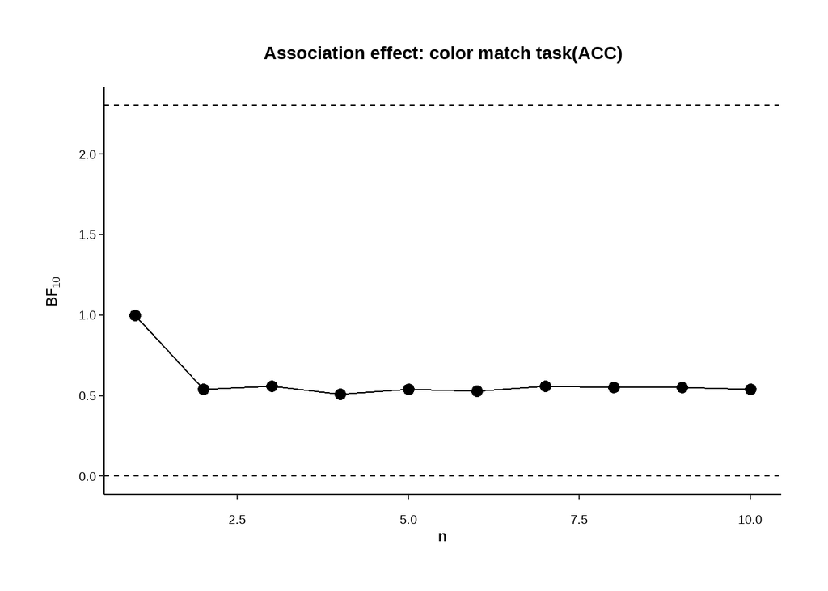

```r
plot_bfs_association <- plot_aov(bfs_association_cm_acc, 'bfs_a', 'Association effect: color match task(ACC)')
plot_bfs_association
```

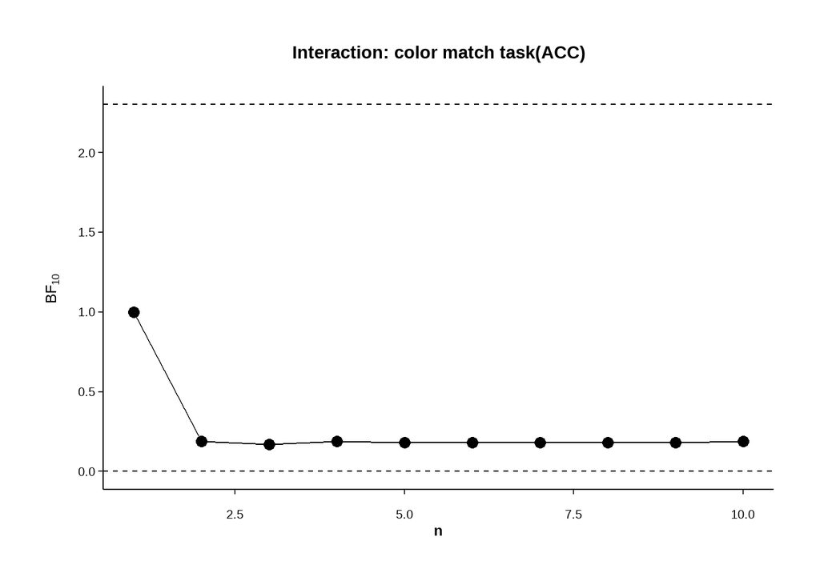

```r
plot_bfs_int <- plot_aov(bfs_association_cm_acc, 'bfs_int', 'Interaction: color match task(ACC)')
plot_bfs_int
```

###### 0.3.2.1.1.2 RT

0.3.2.1.1.2.1 匹配试次

```r
bfs_association_cm_rt <- bf_aov(df_color_match_matchTrial, 'rt', 'association')
```

[output not shown]

```
## # A tibble: 10 × 3
##    bfs_a  bfs_diff bfs_int
##    <dbl>     <dbl>   <dbl>
##  1 1            1    1
##  2 0.851 65762612.   0.198
##  3 0.886 70078503.   0.187
##  4 0.820 67370264.   0.199
##  5 0.853 64643623.   0.203
##  6 0.842 66542176.   0.195
##  7 0.903 70139386.   0.186
##  8 0.873 67146659.   0.196
##  9 0.877 67645899.   0.192
## 10 0.877 68783567.   0.204
```

```r
bfs_association_cm_rt
```

```
## # A tibble: 10 × 3
##    bfs_a  bfs_diff bfs_int
##    <dbl>     <dbl>   <dbl>
##  1 1            1    1
##  2 0.851 65762612.   0.198
##  3 0.886 70078503.   0.187
##  4 0.820 67370264.   0.199
##  5 0.853 64643623.   0.203
##  6 0.842 66542176.   0.195
##  7 0.903 70139386.   0.186
##  8 0.873 67146659.   0.196
##  9 0.877 67645899.   0.192
## 10 0.877 68783567.   0.204
```

**可视化**

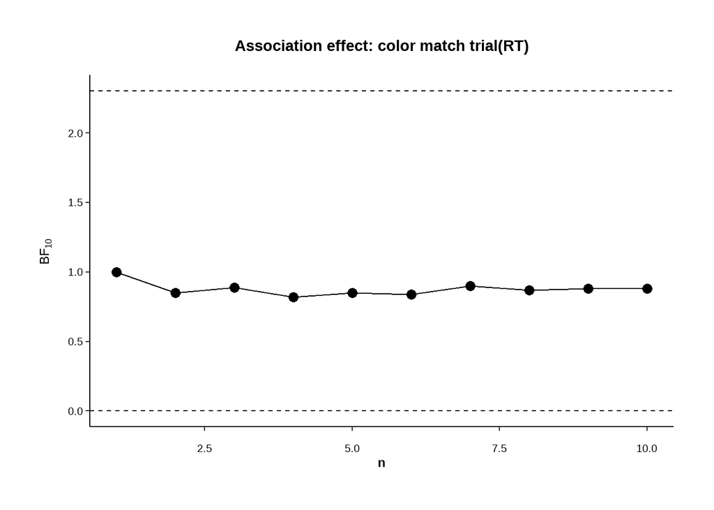

```r
plot_bfs_association <- plot_aov(bfs_association_cm_rt, 'bfs_a', 'Association effect: color match trial(RT)')
plot_bfs_association
```

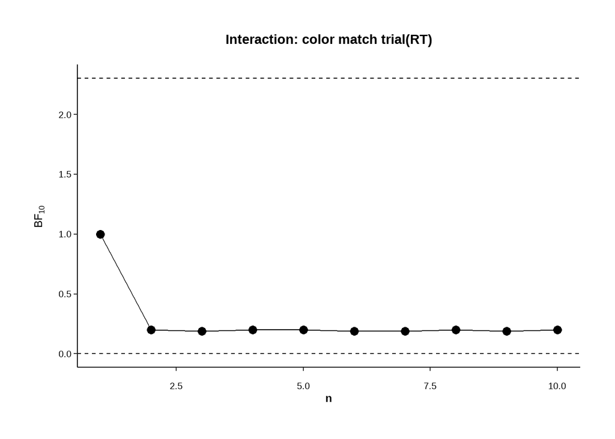

```r
plot_bfs_int <- plot_aov(bfs_association_cm_rt, 'bfs_int', 'Interaction: color match trial(RT)')
plot_bfs_int
```

0.3.2.1.1.2.2 不匹配试次

```r
bfs_association_cnm_rt <- bf_aov(df_color_match_nonmatchTrial, 'rt', 'association')
```

[output not shown]

```
## # A tibble: 10 × 3
##    bfs_a bfs_diff bfs_int
##    <dbl>    <dbl>   <dbl>
##  1  1          1    1
##  2  7.44 4249483.   0.145
##  3  7.73 4574003.   0.137
##  4  7.17 4376833.   0.146
##  5  7.46 4215989.   0.147
##  6  7.30 4369439.   0.142
##  7  7.84 4522706.   0.138
##  8  7.62 4371784.   0.144
##  9  7.62 4407337.   0.141
## 10  7.68 4493789.   0.148
```

```r
bfs_association_cnm_rt
```

```
## # A tibble: 10 × 3
##    bfs_a bfs_diff bfs_int
##    <dbl>    <dbl>   <dbl>
##  1  1          1    1
##  2  7.44 4249483.   0.145
##  3  7.73 4574003.   0.137
##  4  7.17 4376833.   0.146
##  5  7.46 4215989.   0.147
##  6  7.30 4369439.   0.142
##  7  7.84 4522706.   0.138
##  8  7.62 4371784.   0.144
##  9  7.62 4407337.   0.141
## 10  7.68 4493789.   0.148
```

**可视化**

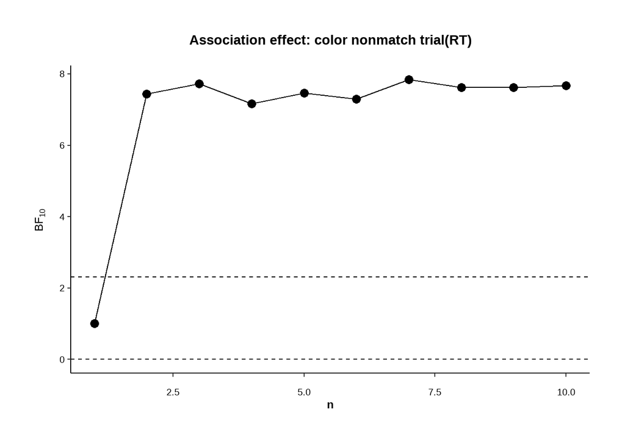

```r
plot_bfs_association <- plot_aov(bfs_association_cnm_rt, 'bfs_a', 'Association effect: color nonmatch trial(RT)')
plot_bfs_association
```

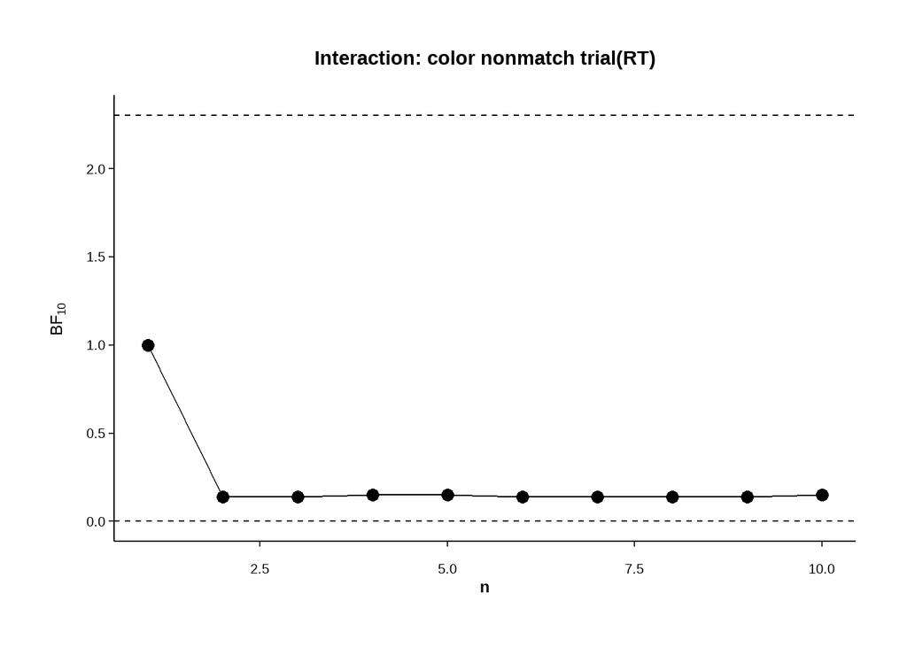

```r
plot_bfs_int <- plot_aov(bfs_association_cnm_rt, 'bfs_int', 'Interaction: color nonmatch trial(RT)')
plot_bfs_int
```

##### 0.3.2.1.2 关联类型和难度的交互效应

###### 0.3.2.1.2.1 ACC

```r
# 调用函数进行不同条件的两两比较
bfs_int_diff_cm_acc <- bf_pairwise_tests(df_color_diff_match, "acc_diff_so_")

# 提取BF值到数据框
bfs_int_diff_cm_acc <- do.call(rbind, lapply(names(bfs_int_diff_cm_acc), function(iter){
  do.call(rbind, lapply(names(bfs_int_diff_cm_acc[[iter]]), function(comparison){
    data.frame(
      subj_idx = iter,
      Effect = comparison,
      BFs = bfs_int_diff_cm_acc[[iter]][[comparison]]$BF,
      Direction = bfs_int_diff_cm_acc[[iter]][[comparison]]$Direction
    )
  }))
})) %>%
  mutate(subj_idx = as.numeric(subj_idx))

bfs_int_diff_cm_acc
```

```
##    subj_idx Effect       BFs    Direction
## 1         2 1 vs 2 0.7829509  0.022192029
## 2         2 1 vs 3 0.6478847  0.068387681
## 3         2 1 vs 4 0.6956672  0.072916667
## 4         2 2 vs 3 0.6223164  0.046195652
## 5         2 2 vs 4 0.6730484  0.050724638
## 6         2 3 vs 4 0.5619135  0.004528986
## 7         3 1 vs 2 0.7236001  0.014794686
## 8         3 1 vs 3 0.7218383  0.080314010
## 9         3 1 vs 4 0.7455793  0.069444444
## 10        3 2 vs 3 0.7153119  0.065519324
## 11        3 2 vs 4 0.7474507  0.054649758
## 12        3 3 vs 4 0.3785156 -0.010869565
## 13        4 1 vs 2 0.3830049 -0.004528986
## 14        4 1 vs 3 0.8522598  0.086277174
```

[output cut: 40 more lines]

**可视化**

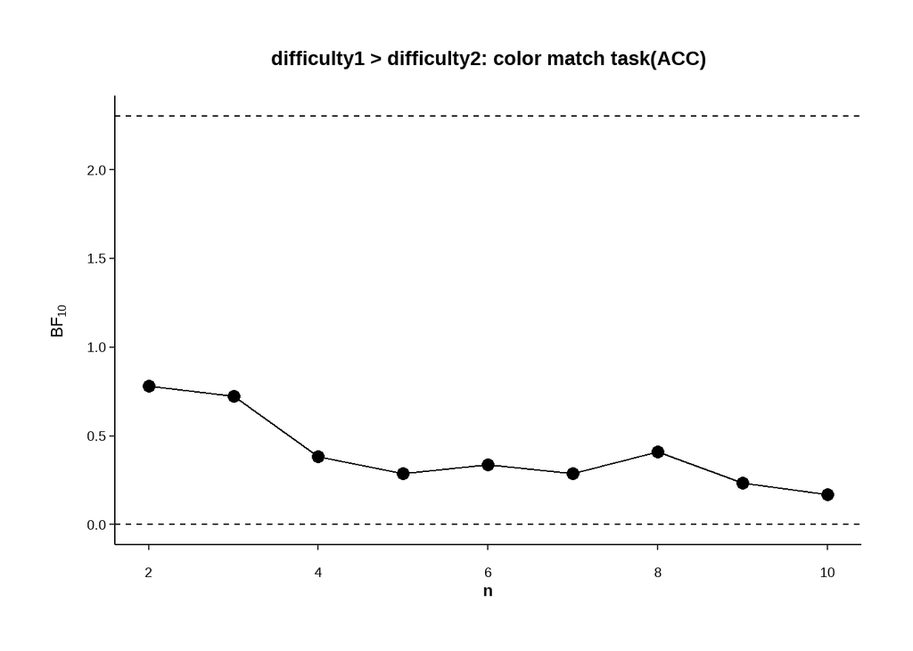

```r
plot_bfs_1vs2 <-
  plot_ttest(bfs_int_diff_cm_acc, '1 vs 2', 'difficulty1 > difficulty2: color match task(ACC)')
plot_bfs_1vs2
```

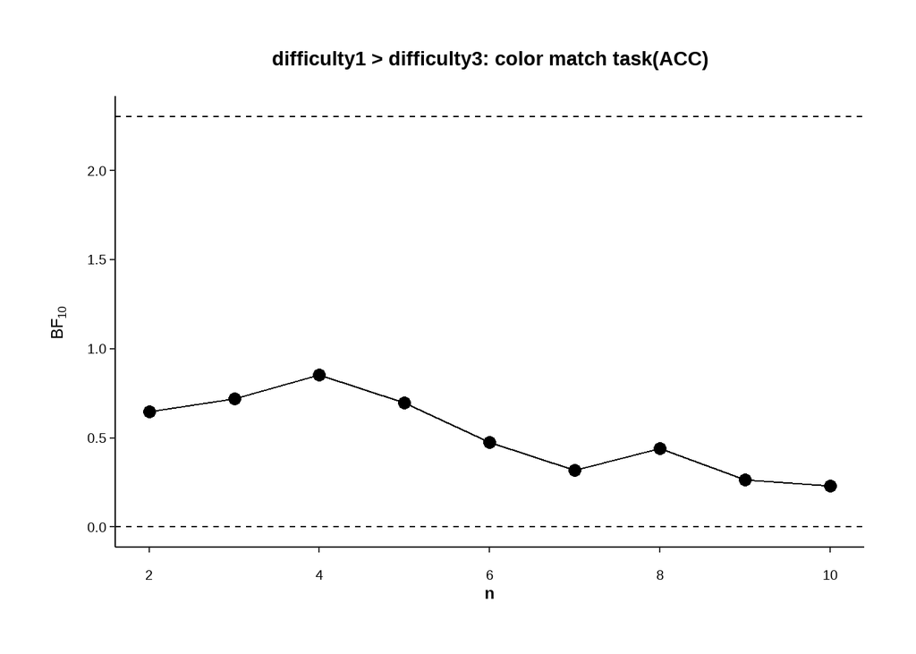

```r
plot_bfs_1vs3 <-
  plot_ttest(bfs_int_diff_cm_acc, '1 vs 3', 'difficulty1 > difficulty3: color match task(ACC)')
plot_bfs_1vs3
```

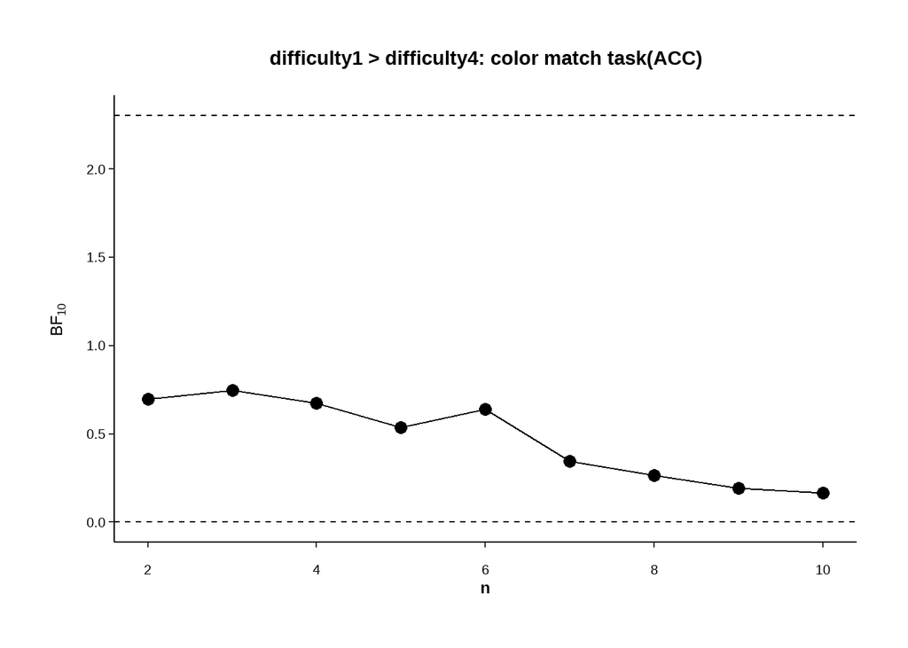

```r
plot_bfs_1vs4 <-
  plot_ttest(bfs_int_diff_cm_acc, '1 vs 4', 'difficulty1 > difficulty4: color match task(ACC)')
plot_bfs_1vs4
```

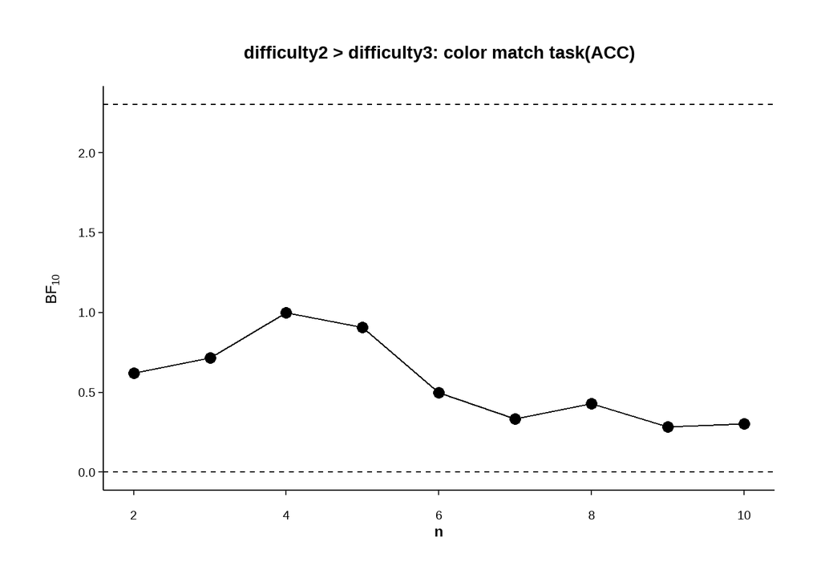

```r
plot_bfs_2vs3 <-
  plot_ttest(bfs_int_diff_cm_acc, '2 vs 3', 'difficulty2 > difficulty3: color match task(ACC)')
plot_bfs_2vs3
```

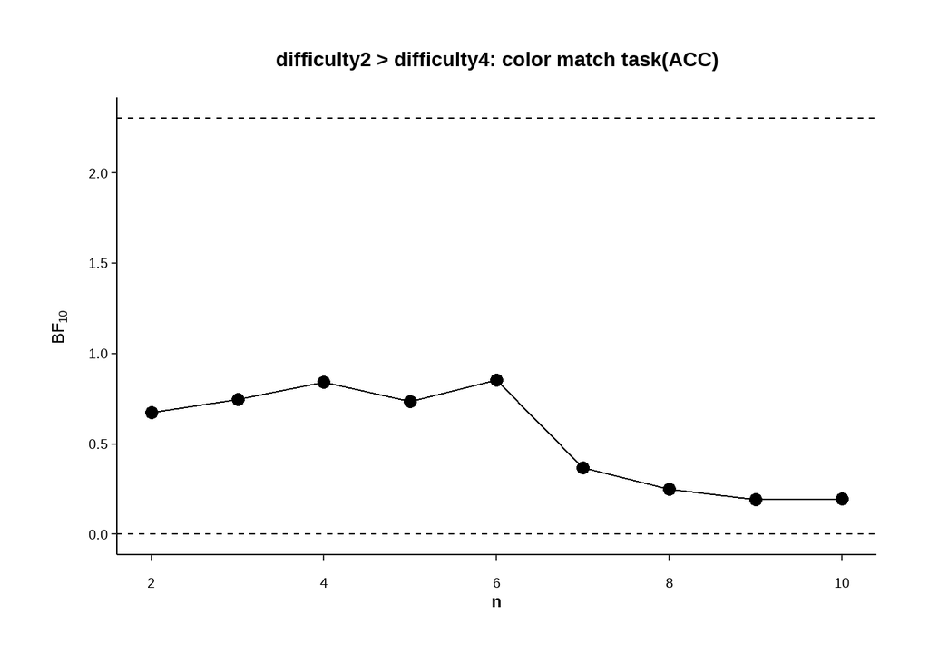

```r
plot_bfs_2vs4 <-
  plot_ttest(bfs_int_diff_cm_acc, '2 vs 4', 'difficulty2 > difficulty4: color match task(ACC)')
plot_bfs_2vs4
```

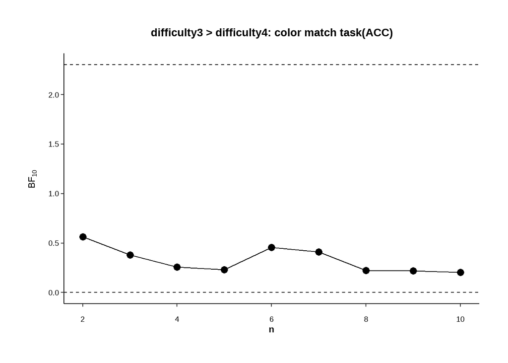

```r
plot_bfs_3vs4 <-
  plot_ttest(bfs_int_diff_cm_acc, '3 vs 4', 'difficulty3 > difficulty4: color match task(ACC)')
plot_bfs_3vs4
```

**查看数据的变化趋势**

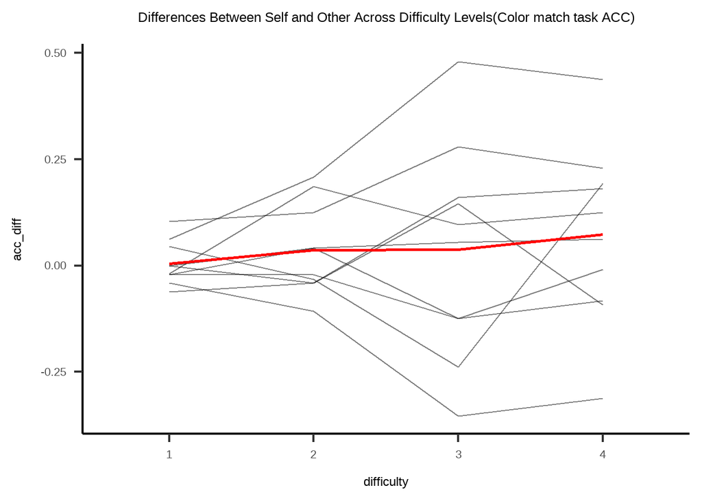

```r
# 转为长数据
df_color_diff_match_long <- df_color_diff_match %>%
  tidyr::pivot_longer(
    cols = starts_with(c("acc_diff_so", "rt_diff_os")),
    names_to = c(".value", "difficulty"),
    names_pattern = "^(acc_diff|rt_diff)_[^_]+_(\\d+)$",  # 简化正则表达式
    values_drop_na = TRUE
  )

ggplot(df_color_diff_match_long, aes(x = difficulty, y = acc_diff, group = subj_idx)) +
  geom_line(alpha = 0.5) +
  stat_summary(aes(group = 1), fun = mean, geom = "line", color = "red", size = 1) + labs(title = "Differences Between Self and Other Across Difficulty Levels(Color match task ACC)") +
  papaja::theme_apa(base_size = 18, # base_family = "Times"
                    )
```

###### 0.3.2.1.2.2 RT

0.3.2.1.2.2.1 匹配试次

```r
# 调用函数进行不同条件的两两比较
bfs_int_diff_cm_rt <- bf_pairwise_tests(df_color_diff_match_matchTrial, "rt_diff_os_")

# 提取BF值到数据框
bfs_int_diff_cm_rt <- do.call(rbind, lapply(names(bfs_int_diff_cm_rt), function(iter){
  do.call(rbind, lapply(names(bfs_int_diff_cm_rt[[iter]]), function(comparison){
    data.frame(
      subj_idx = iter,
      Effect = comparison,
      BFs = bfs_int_diff_cm_rt[[iter]][[comparison]]$BF,
      Direction = bfs_int_diff_cm_rt[[iter]][[comparison]]$Direction
    )
  }))
})) %>%
  mutate(subj_idx = as.numeric(subj_idx))

bfs_int_diff_cm_rt
```

```
##    subj_idx Effect       BFs    Direction
## 1         2 1 vs 2 1.2399651  164.9166667
## 2         2 1 vs 3 0.7538112   51.0525362
## 3         2 1 vs 4 0.4038084  -64.3125000
## 4         2 2 vs 3 0.4055805 -113.8641304
## 5         2 2 vs 4 0.3628467 -229.2291667
## 6         2 3 vs 4 0.3137758 -115.3650362
## 7         3 1 vs 2 1.6533961  140.5833333
## 8         3 1 vs 3 1.2157691   92.9100242
## 9         3 1 vs 4 0.4521862   -4.8194444
## 10        3 2 vs 3 0.3886142  -47.6733092
## 11        3 2 vs 4 0.3147759 -145.4027778
## 12        3 3 vs 4 0.2417056  -97.7294686
## 13        4 1 vs 2 1.4312404  103.0729167
## 14        4 1 vs 3 1.3044920   76.1512681
```

[output cut: 40 more lines]

**可视化**

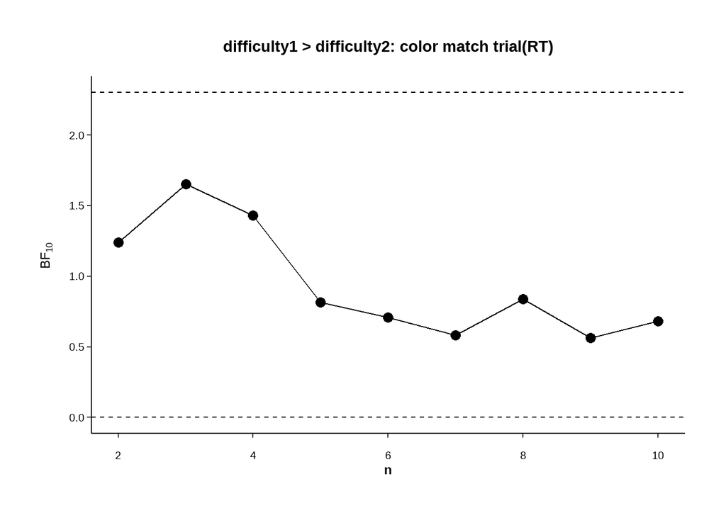

```r
plot_bfs_1vs2 <-
  plot_ttest(bfs_int_diff_cm_rt, '1 vs 2', 'difficulty1 > difficulty2: color match trial(RT)')
plot_bfs_1vs2
```

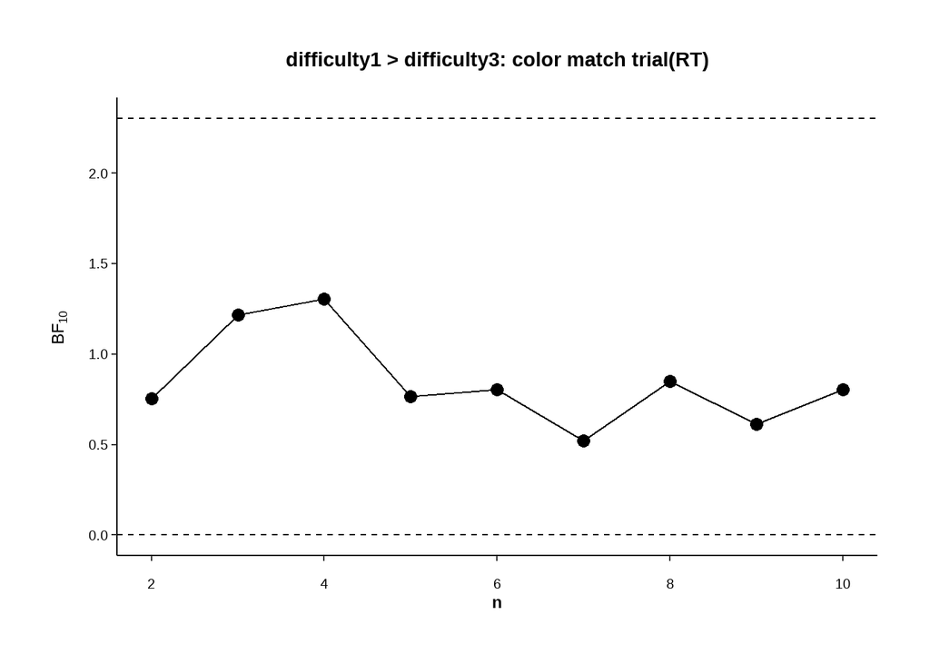

```r
plot_bfs_1vs3 <-
  plot_ttest(bfs_int_diff_cm_rt, '1 vs 3', 'difficulty1 > difficulty3: color match trial(RT)')
plot_bfs_1vs3
```

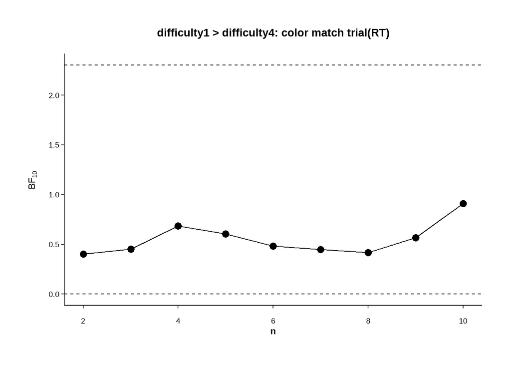

```r
plot_bfs_1vs4 <-
  plot_ttest(bfs_int_diff_cm_rt, '1 vs 4', 'difficulty1 > difficulty4: color match trial(RT)')
plot_bfs_1vs4
```

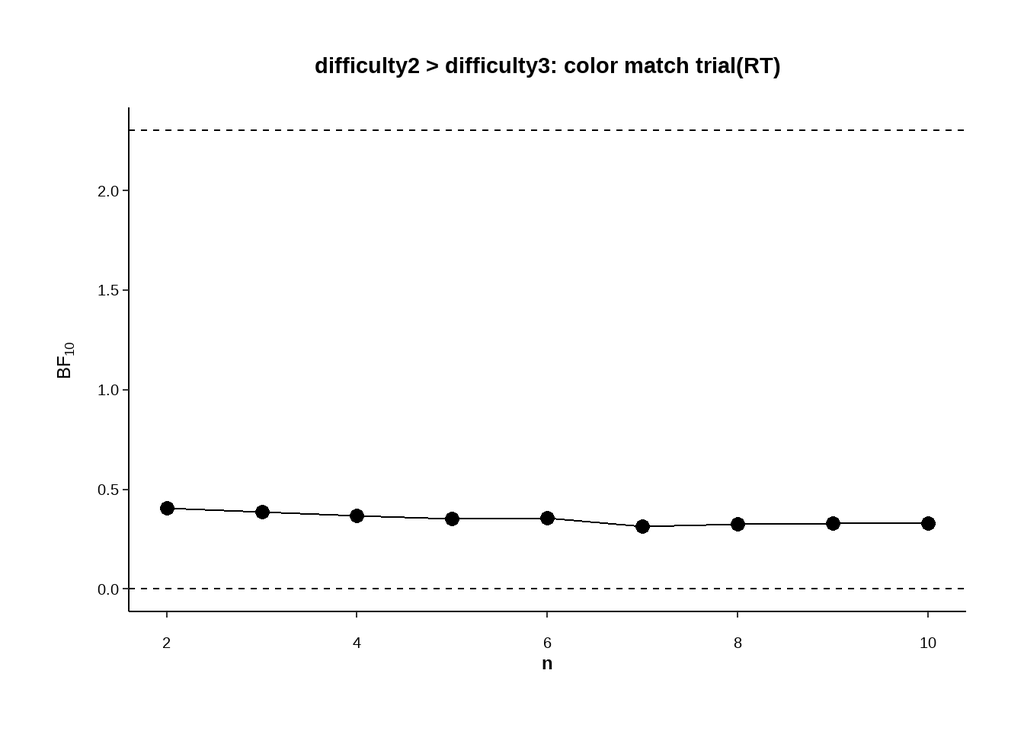

```r
plot_bfs_2vs3 <-
  plot_ttest(bfs_int_diff_cm_rt, '2 vs 3', 'difficulty2 > difficulty3: color match trial(RT)')
plot_bfs_2vs3
```

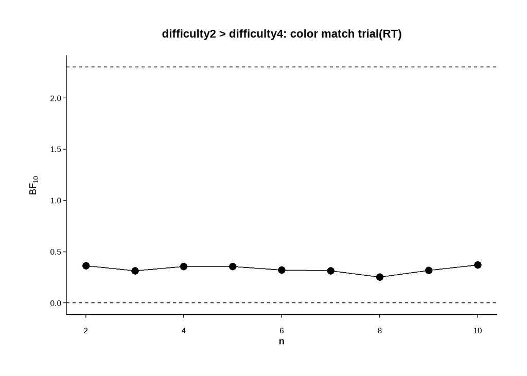

```r
plot_bfs_2vs4 <-
  plot_ttest(bfs_int_diff_cm_rt, '2 vs 4', 'difficulty2 > difficulty4: color match trial(RT)')
plot_bfs_2vs4
```

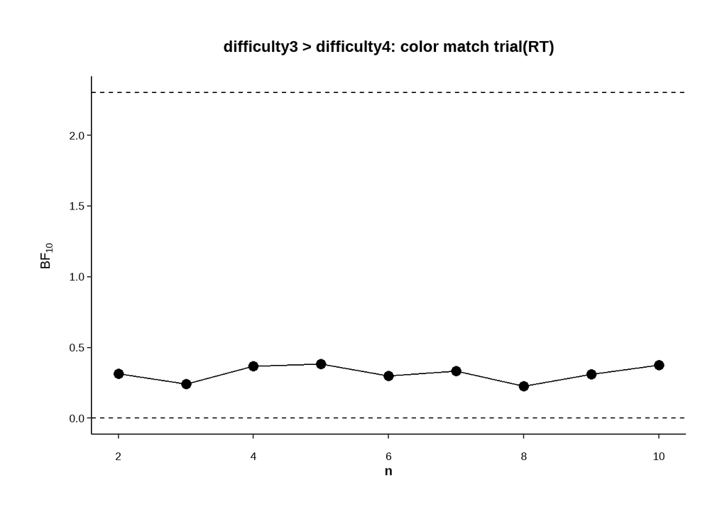

```r
plot_bfs_3vs4 <-
  plot_ttest(bfs_int_diff_cm_rt, '3 vs 4', 'difficulty3 > difficulty4: color match trial(RT)')
plot_bfs_3vs4
```

0.3.2.1.2.2.2 不匹配试次

```r
# 调用函数进行不同条件的两两比较
bfs_int_diff_cnm_rt <- bf_pairwise_tests(df_color_diff_match_nonmatchTrial, "rt_diff_os_")

# 提取BF值到数据框
bfs_int_diff_cnm_rt <- do.call(rbind, lapply(names(bfs_int_diff_cnm_rt), function(iter){
  do.call(rbind, lapply(names(bfs_int_diff_cnm_rt[[iter]]), function(comparison){
    data.frame(
      subj_idx = iter,
      Effect = comparison,
      BFs = bfs_int_diff_cnm_rt[[iter]][[comparison]]$BF,
      Direction = bfs_int_diff_cnm_rt[[iter]][[comparison]]$Direction
    )
  }))
})) %>%
  mutate(subj_idx = as.numeric(subj_idx))

bfs_int_diff_cnm_rt
```

```
##    subj_idx Effect       BFs   Direction
## 1         2 1 vs 2 0.4780124  -6.9900362
## 2         2 1 vs 3 0.3429517 -31.6041667
## 3         2 1 vs 4 0.8265884  45.9791667
## 4         2 2 vs 3 0.3516119 -24.6141304
## 5         2 2 vs 4 0.7180297  52.9692029
## 6         2 3 vs 4 0.9264164  77.5833333
## 7         3 1 vs 2 0.4522398  -1.4655797
## 8         3 1 vs 3 0.6061663  18.3750000
## 9         3 1 vs 4 0.9773057  42.8750000
## 10        3 2 vs 3 0.6429909  19.8405797
## 11        3 2 vs 4 0.7333094  44.3405797
## 12        3 3 vs 4 0.5838121  24.5000000
## 13        4 1 vs 2 0.2835718 -25.3179348
## 14        4 1 vs 3 0.8982769  39.0833333
```

[output cut: 40 more lines]

**可视化**

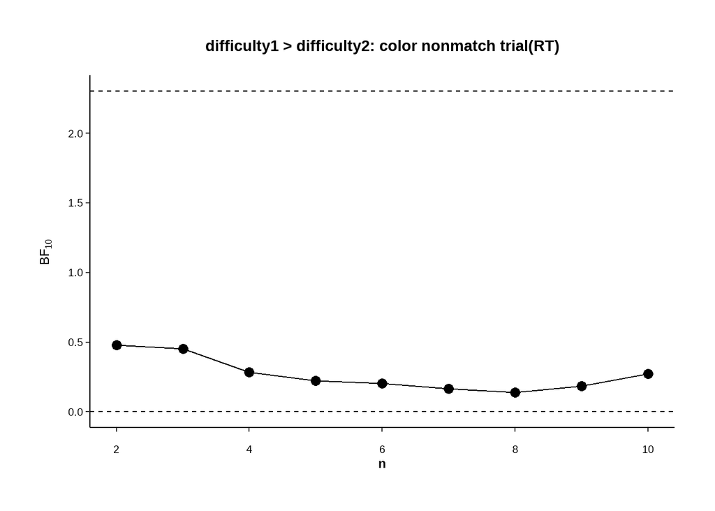

```r
plot_bfs_1vs2 <-
  plot_ttest(bfs_int_diff_cnm_rt, '1 vs 2', 'difficulty1 > difficulty2: color nonmatch trial(RT)')
plot_bfs_1vs2
```

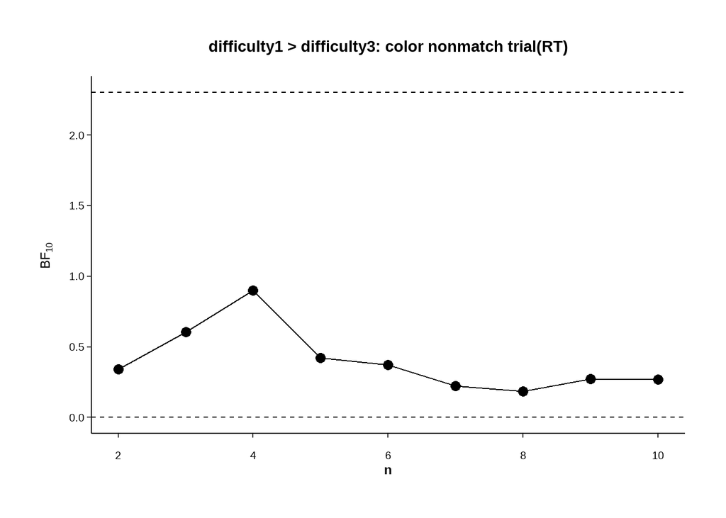

```r
plot_bfs_1vs3 <-
  plot_ttest(bfs_int_diff_cnm_rt, '1 vs 3', 'difficulty1 > difficulty3: color nonmatch trial(RT)')
plot_bfs_1vs3
```

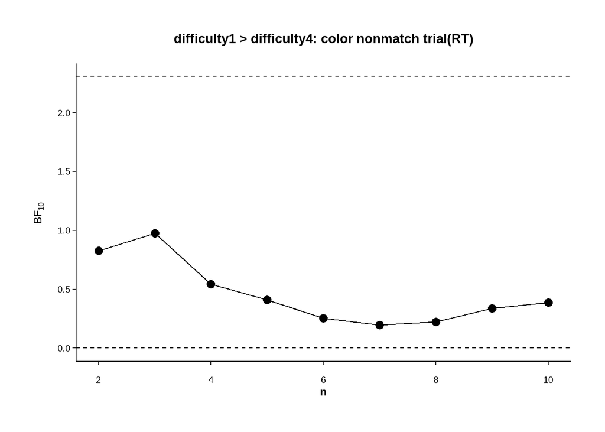

```r
plot_bfs_1vs4 <-
  plot_ttest(bfs_int_diff_cnm_rt, '1 vs 4', 'difficulty1 > difficulty4: color nonmatch trial(RT)')
plot_bfs_1vs4
```

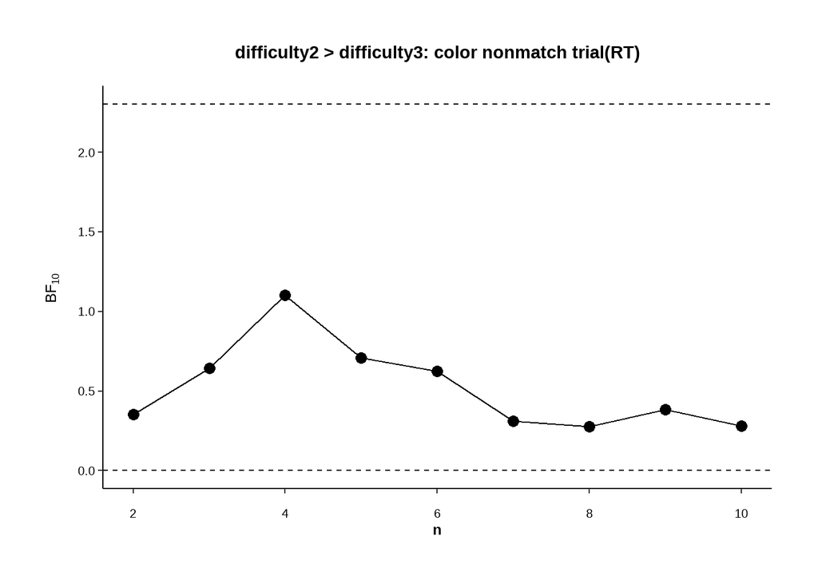

```r
plot_bfs_2vs3 <-
  plot_ttest(bfs_int_diff_cnm_rt, '2 vs 3', 'difficulty2 > difficulty3: color nonmatch trial(RT)')
plot_bfs_2vs3
```

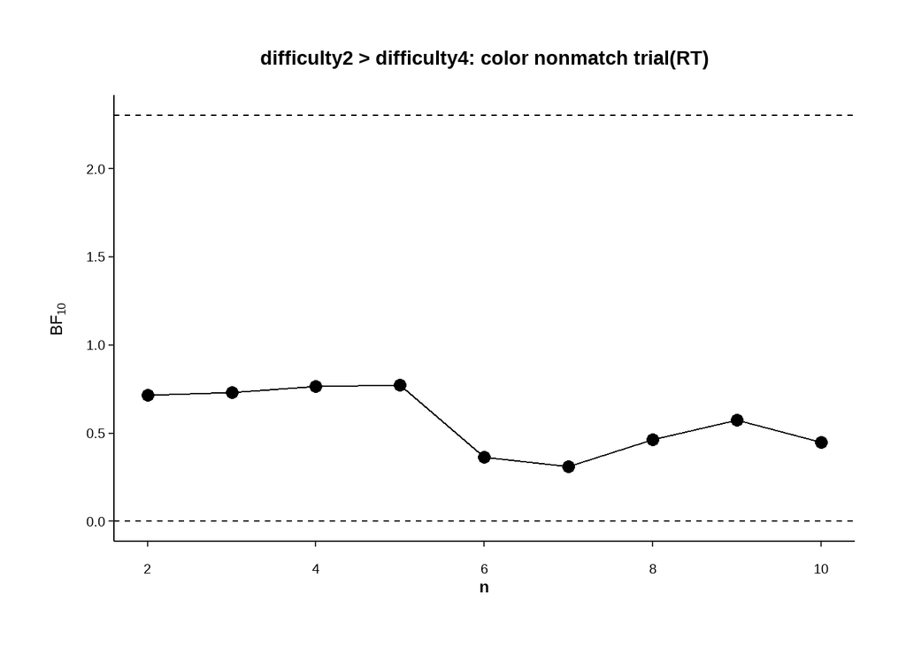

```r
plot_bfs_2vs4 <-
  plot_ttest(bfs_int_diff_cnm_rt, '2 vs 4', 'difficulty2 > difficulty4: color nonmatch trial(RT)')
plot_bfs_2vs4
```

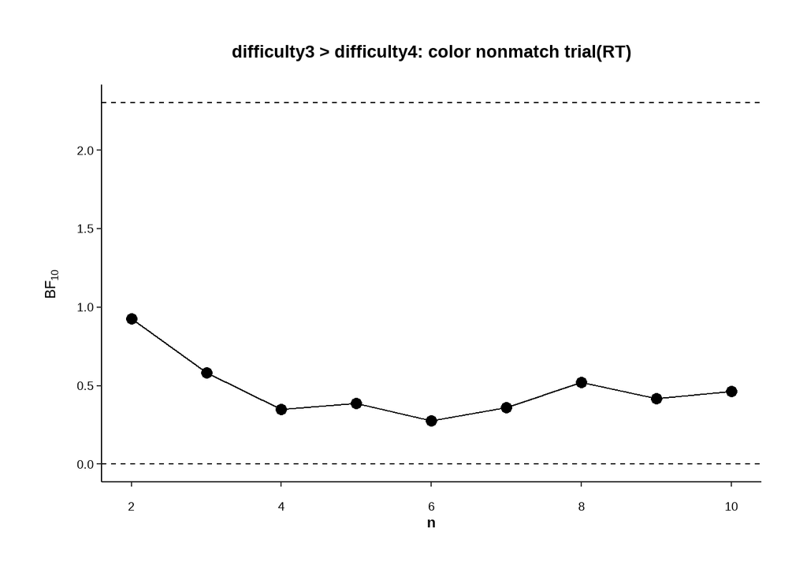

```r
plot_bfs_3vs4 <-
  plot_ttest(bfs_int_diff_cnm_rt, '3 vs 4', 'difficulty3 > difficulty4: color nonmatch trial(RT)')
plot_bfs_3vs4
```

**查看数据的变化趋势**

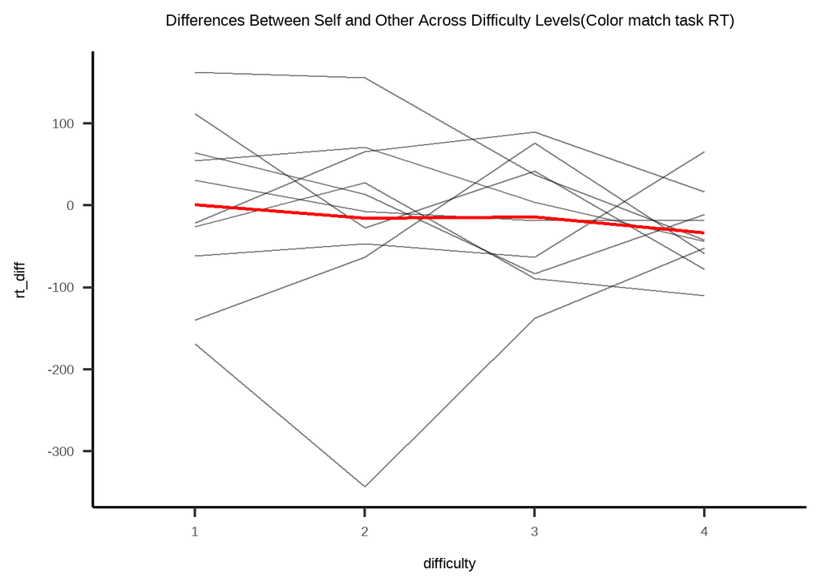

```r
ggplot(df_color_diff_match_long, aes(x = difficulty, y = rt_diff, group = subj_idx)) +
  geom_line(alpha = 0.5) +
  stat_summary(aes(group = 1), fun = mean, geom = "line", color = "red", size = 1) + labs(title = "Differences Between Self and Other Across Difficulty Levels(Color match task RT)") +
  papaja::theme_apa(base_size = 18,# base_family = "Times"
                    )
```

#### 0.3.2.2 辨别任务

##### 0.3.2.2.1 关联类型主效应

###### 0.3.2.2.1.1 ACC

```r
bfs_association_cr_acc <- bf_aov(df_color_rdk, 'acc', 'association')
```

[output not shown]

```
## # A tibble: 10 × 3
##    bfs_a    bfs_diff bfs_int
##    <dbl>       <dbl>   <dbl>
##  1 1              1     1
##  2 0.770 1961820836.    1.45
##  3 0.781 2013901502.    1.41
##  4 0.741 1964685390.    1.47
##  5 0.775 1923642593.    1.48
##  6 0.749 1893501261.    1.45
##  7 0.811 2074284495.    1.36
##  8 0.785 1970608463.    1.46
##  9 0.801 2032385756.    1.39
## 10 0.794 2055235696.    1.48
```

```r
bfs_association_cr_acc
```

```
## # A tibble: 10 × 3
##    bfs_a    bfs_diff bfs_int
##    <dbl>       <dbl>   <dbl>
##  1 1              1     1
##  2 0.770 1961820836.    1.45
##  3 0.781 2013901502.    1.41
##  4 0.741 1964685390.    1.47
##  5 0.775 1923642593.    1.48
##  6 0.749 1893501261.    1.45
##  7 0.811 2074284495.    1.36
##  8 0.785 1970608463.    1.46
##  9 0.801 2032385756.    1.39
## 10 0.794 2055235696.    1.48
```

**可视化**

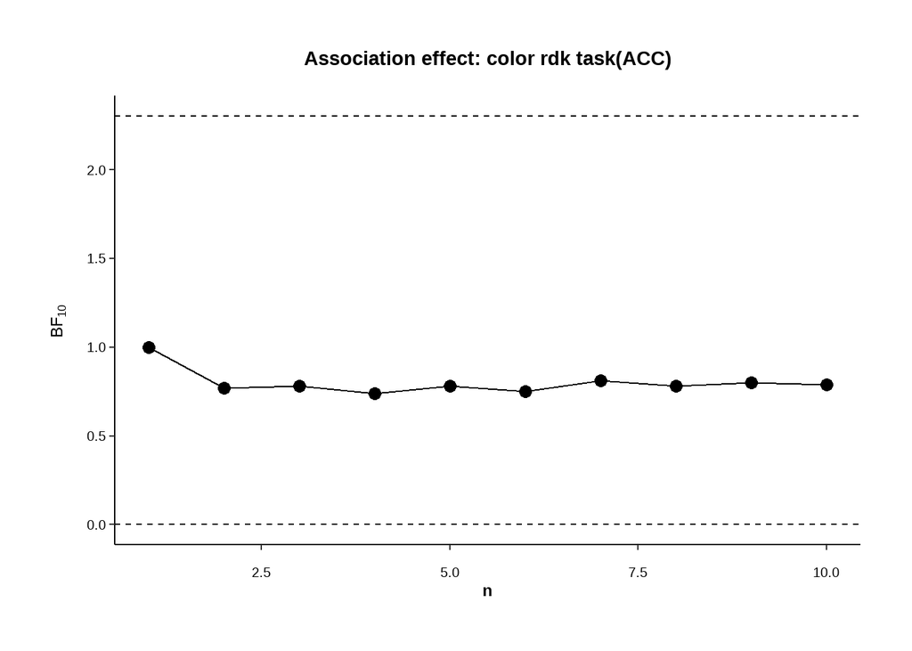

```r
plot_bfs_association <- plot_aov(bfs_association_cr_acc, 'bfs_a', 'Association effect: color rdk task(ACC)')
plot_bfs_association
```

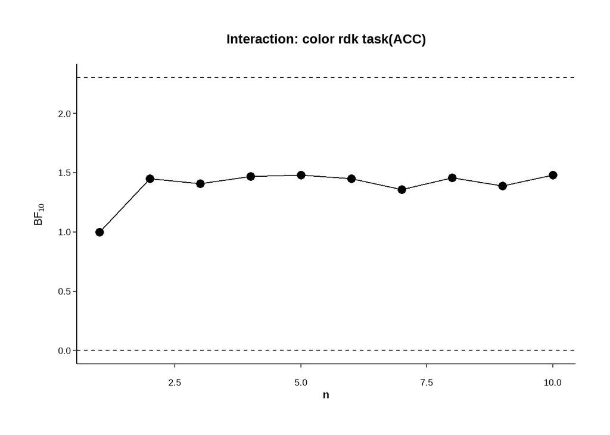

```r
plot_bfs_int <- plot_aov(bfs_association_cr_acc, 'bfs_int', 'Interaction: color rdk task(ACC)')
plot_bfs_int
```

###### 0.3.2.2.1.2 RT

```r
bfs_association_cr_rt <- bf_aov(df_color_rdk, 'rt', 'association')
```

[output not shown]

```
## # A tibble: 10 × 3
##    bfs_a bfs_diff bfs_int
##    <dbl>    <dbl>   <dbl>
##  1 1           1    1
##  2 0.662    1780.   0.254
##  3 0.702    1952.   0.231
##  4 0.649    1856.   0.246
##  5 0.674    1750.   0.257
##  6 0.666    1817.   0.243
##  7 0.715    1906.   0.232
##  8 0.680    1849.   0.243
##  9 0.680    1806.   0.245
## 10 0.690    1863.   0.260
```

```r
bfs_association_cr_rt
```

```
## # A tibble: 10 × 3
##    bfs_a bfs_diff bfs_int
##    <dbl>    <dbl>   <dbl>
##  1 1           1    1
##  2 0.662    1780.   0.254
##  3 0.702    1952.   0.231
##  4 0.649    1856.   0.246
##  5 0.674    1750.   0.257
##  6 0.666    1817.   0.243
##  7 0.715    1906.   0.232
##  8 0.680    1849.   0.243
##  9 0.680    1806.   0.245
## 10 0.690    1863.   0.260
```

**可视化**

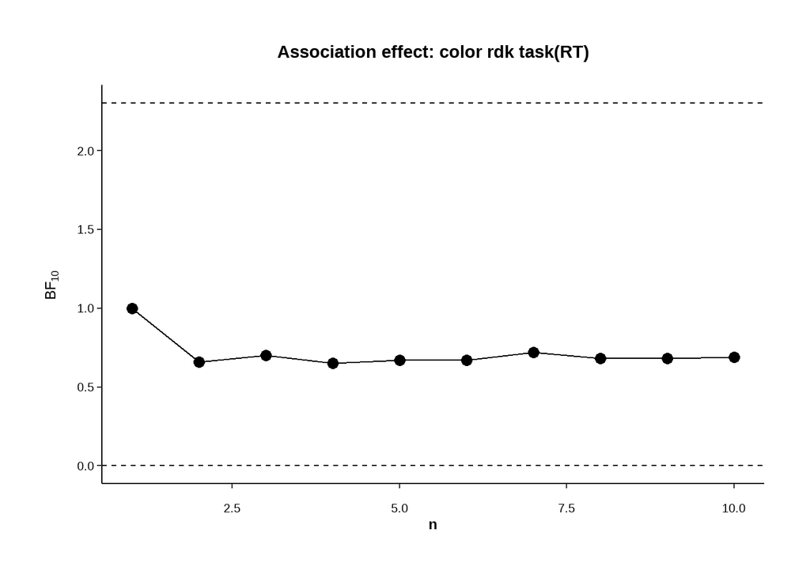

```r
plot_bfs_association <- plot_aov(bfs_association_cr_rt, 'bfs_a', 'Association effect: color rdk task(RT)')
plot_bfs_association
```

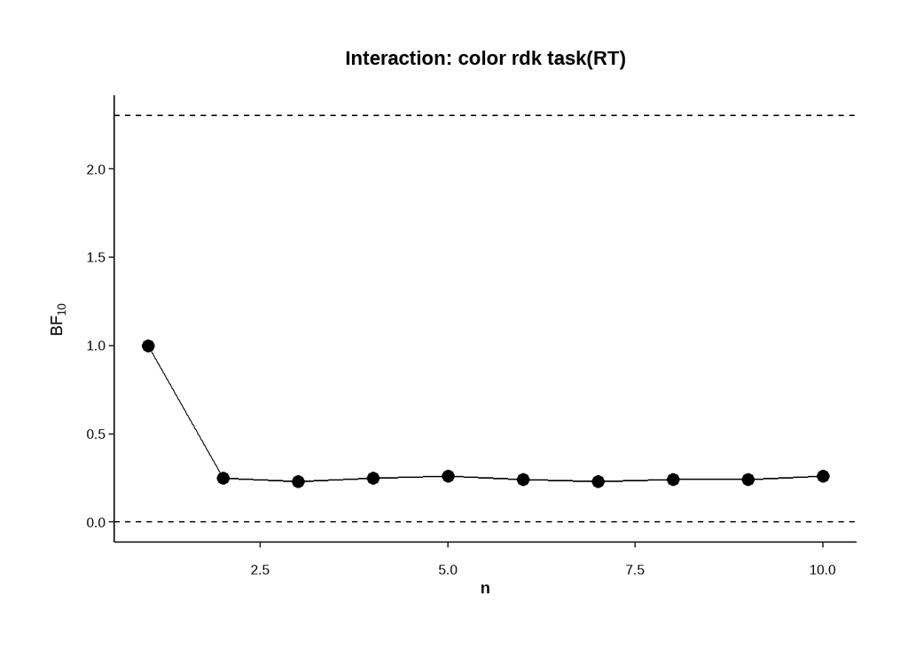

```r
plot_bfs_int <- plot_aov(bfs_association_cr_rt, 'bfs_int', 'Interaction: color rdk task(RT)')
plot_bfs_int
```

##### 0.3.2.2.2 关联类型和难度的交互效应

###### 0.3.2.2.2.1 ACC

```r
# 调用函数进行不同条件的两两比较
bfs_int_diff_cr_acc <-bf_pairwise_tests(df_color_diff_rdk, "acc_diff_so_")

# 提取BF值到数据框
bfs_int_diff_cr_acc <- do.call(rbind, lapply(names(bfs_int_diff_cr_acc), function(iter){
  do.call(rbind, lapply(names(bfs_int_diff_cr_acc[[iter]]), function(comparison){
    data.frame(
      subj_idx = iter,
      Effect = comparison,
      BFs = bfs_int_diff_cr_acc[[iter]][[comparison]]$BF,
      Direction = bfs_int_diff_cr_acc[[iter]][[comparison]]$Direction
    )
  }))
})) %>%
  mutate(subj_idx = as.numeric(subj_idx))

bfs_int_diff_cr_acc
```

```
##    subj_idx Effect       BFs    Direction
## 1         2 1 vs 2 0.3517081 -0.020833333
## 2         2 1 vs 3 0.3857510 -0.125000000
## 3         2 1 vs 4 0.5231566  0.000000000
## 4         2 2 vs 3 0.4064236 -0.104166667
## 5         2 2 vs 4 0.5531147  0.020833333
## 6         2 3 vs 4 2.2806785  0.125000000
## 7         3 1 vs 2 0.2986952 -0.013888889
## 8         3 1 vs 3 0.3169209 -0.097222222
## 9         3 1 vs 4 0.4994689  0.013888889
## 10        3 2 vs 3 0.3357477 -0.083333333
## 11        3 2 vs 4 0.5302333  0.027777778
## 12        3 3 vs 4 4.4747182  0.111111111
## 13        4 1 vs 2 0.2421586 -0.013392857
## 14        4 1 vs 3 0.2367347 -0.154356061
```

[output cut: 40 more lines]

**可视化**

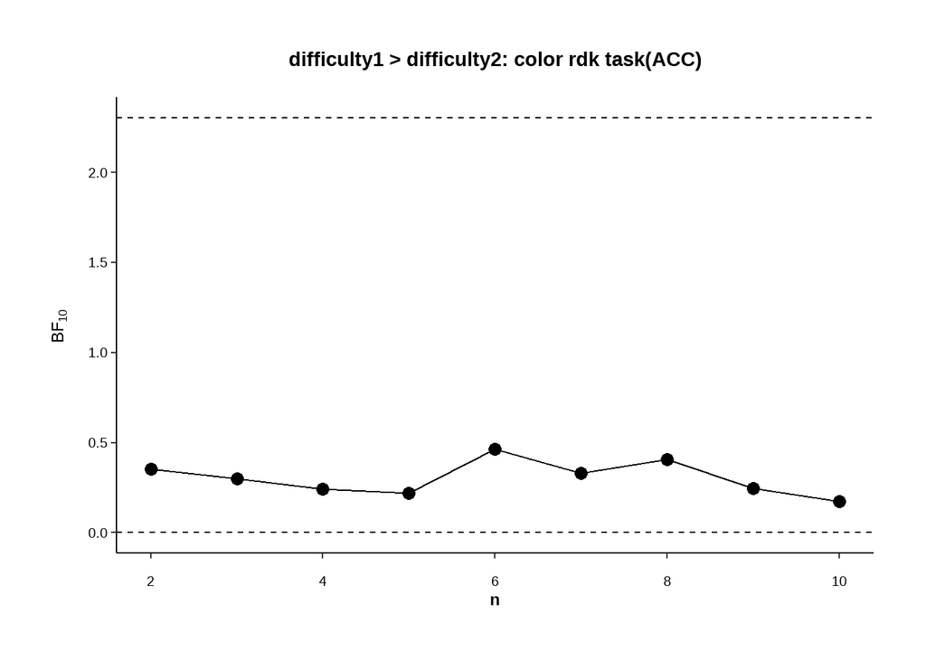

```r
plot_bfs_1vs2 <-
  plot_ttest(bfs_int_diff_cr_acc, '1 vs 2', 'difficulty1 > difficulty2: color rdk task(ACC)')
plot_bfs_1vs2
```

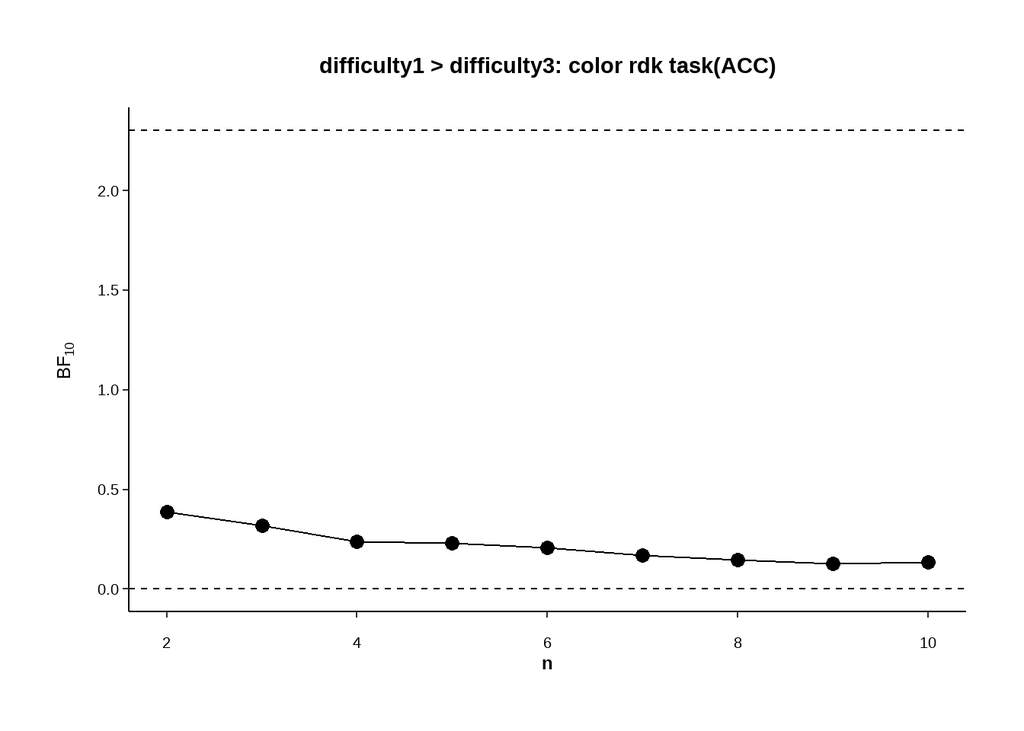

```r
plot_bfs_1vs3 <-
  plot_ttest(bfs_int_diff_cr_acc, '1 vs 3', 'difficulty1 > difficulty3: color rdk task(ACC)')
plot_bfs_1vs3
```

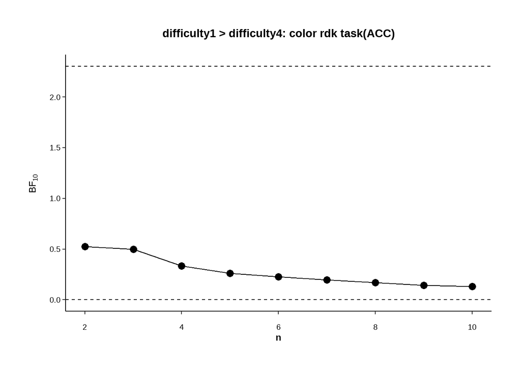

```r
plot_bfs_1vs4 <-
  plot_ttest(bfs_int_diff_cr_acc, '1 vs 4', 'difficulty1 > difficulty4: color rdk task(ACC)')
plot_bfs_1vs4
```

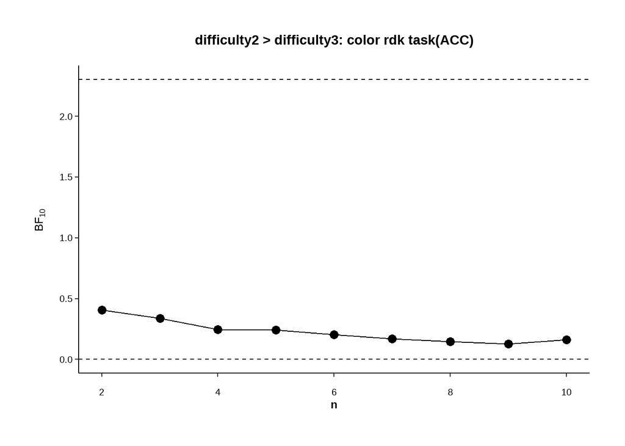

```r
plot_bfs_2vs3 <-
  plot_ttest(bfs_int_diff_cr_acc, '2 vs 3', 'difficulty2 > difficulty3: color rdk task(ACC)')
plot_bfs_2vs3
```

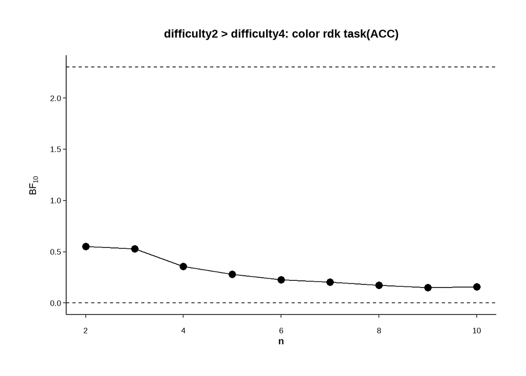

```r
plot_bfs_2vs4 <-
  plot_ttest(bfs_int_diff_cr_acc, '2 vs 4', 'difficulty2 > difficulty4: color rdk task(ACC)')
plot_bfs_2vs4
```

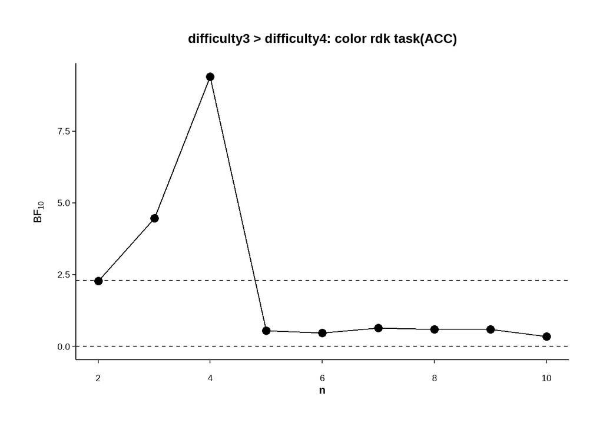

```r
plot_bfs_3vs4 <-
  plot_ttest(bfs_int_diff_cr_acc, '3 vs 4', 'difficulty3 > difficulty4: color rdk task(ACC)')
plot_bfs_3vs4
```

**查看数据的变化趋势**

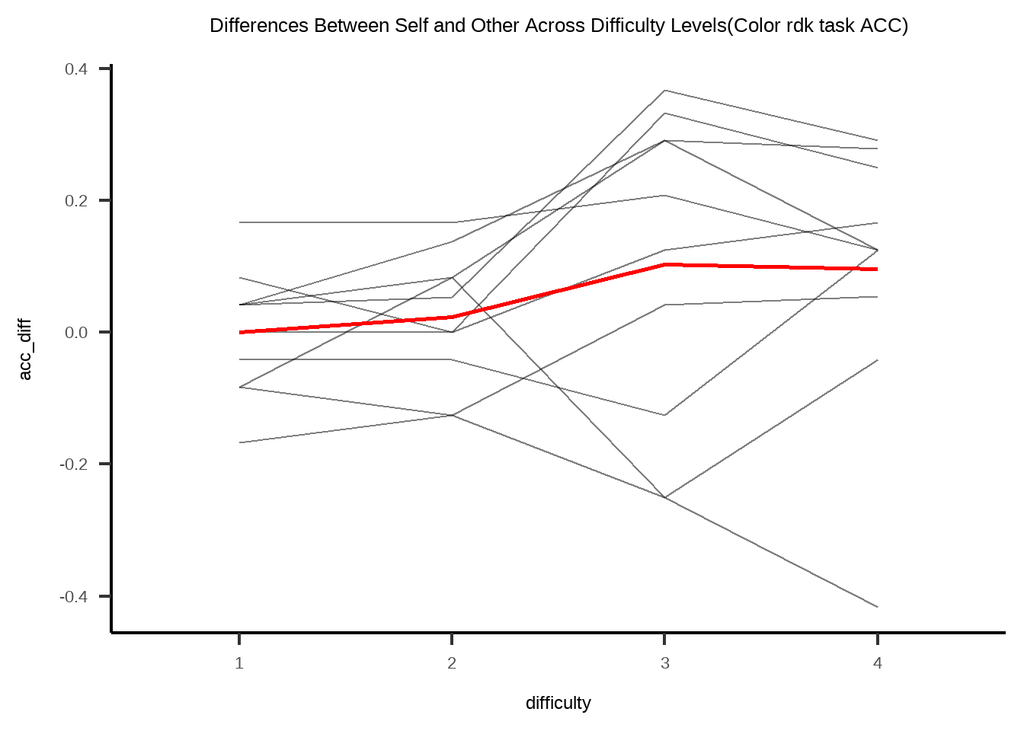

```r
# 转为长数据
df_color_diff_rdk_long <- df_color_diff_rdk %>%
  tidyr::pivot_longer(
    cols = starts_with(c("acc_diff_so", "rt_diff_os")),
    names_to = c(".value", "difficulty"),
    names_pattern = "^(acc_diff|rt_diff)_[^_]+_(\\d+)$",  # 简化正则表达式
    values_drop_na = TRUE
  )

ggplot(df_color_diff_rdk_long, aes(x = difficulty, y = acc_diff, group = subj_idx)) +
  geom_line(alpha = 0.5) +
  stat_summary(aes(group = 1), fun = mean, geom = "line", color = "red", size = 1) + labs(title = "Differences Between Self and Other Across Difficulty Levels(Color rdk task ACC)") +
  papaja::theme_apa(base_size = 18, # base_family = "Times"
                    )
```

###### 0.3.2.2.2.2 RT

```r
# 调用函数进行不同条件的两两比较
bfs_int_diff_cr_rt <- bf_pairwise_tests(df_color_diff_rdk, "rt_diff_os_")

# 提取BF值到数据框
bfs_int_diff_cr_rt <- do.call(rbind, lapply(names(bfs_int_diff_cr_rt), function(iter){
  do.call(rbind, lapply(names(bfs_int_diff_cr_rt[[iter]]), function(comparison){
    data.frame(
      subj_idx = iter,
      Effect = comparison,
      BFs = bfs_int_diff_cr_rt[[iter]][[comparison]]$BF,
      Direction = bfs_int_diff_cr_rt[[iter]][[comparison]]$Direction
    )
  }))
})) %>%
  mutate(subj_idx = as.numeric(subj_idx))

bfs_int_diff_cr_rt
```

```
##    subj_idx Effect       BFs    Direction
## 1         2 1 vs 2 0.4855818  -5.02083333
## 2         2 1 vs 3 0.3948748 -30.70833333
## 3         2 1 vs 4 0.4917805 -13.68750000
## 4         2 2 vs 3 0.4476387 -25.68750000
## 5         2 2 vs 4 0.5073323  -8.66666667
## 6         2 3 vs 4 0.6008084  17.02083333
## 7         3 1 vs 2 0.6150148  11.38888889
## 8         3 1 vs 3 0.3850190 -12.22222222
## 9         3 1 vs 4 0.5867967  30.04166667
## 10        3 2 vs 3 0.3703615 -23.61111111
## 11        3 2 vs 4 0.5237869  18.65277778
## 12        3 3 vs 4 0.8166726  42.26388889
## 13        4 1 vs 2 0.3960743  -3.03869048
## 14        4 1 vs 3 0.2585708 -53.34943182
```

[output cut: 40 more lines]

**可视化**

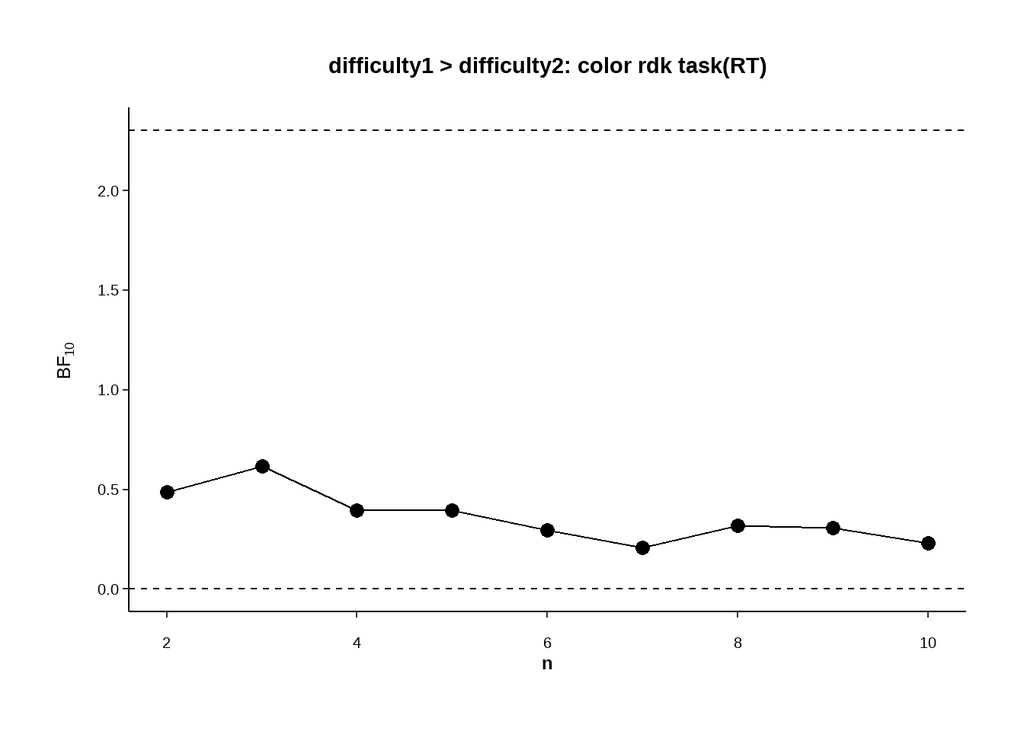

```r
plot_bfs_1vs2 <-
  plot_ttest(bfs_int_diff_cr_rt, '1 vs 2', 'difficulty1 > difficulty2: color rdk task(RT)')
plot_bfs_1vs2
```

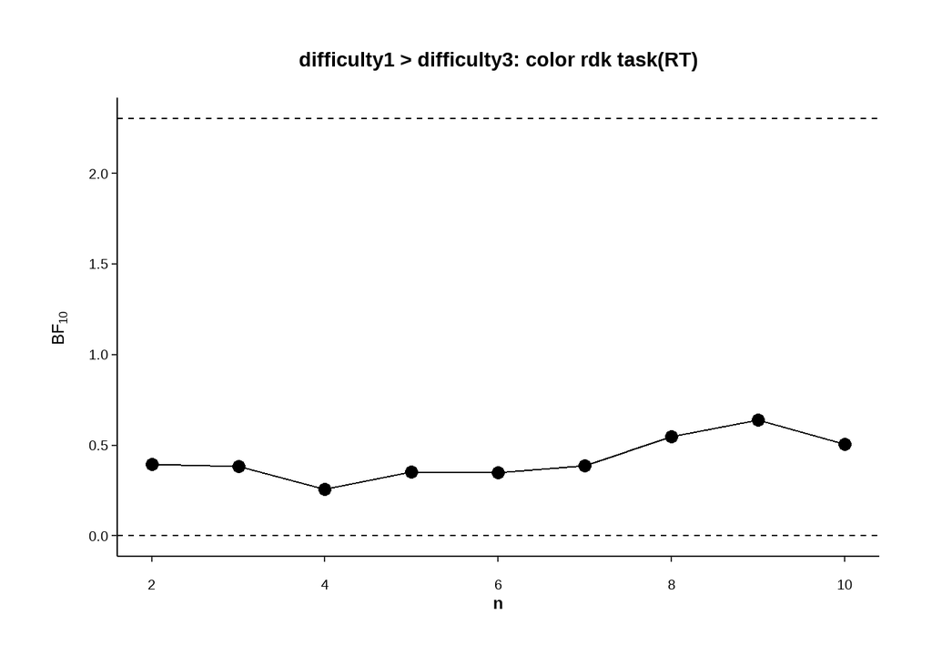

```r
plot_bfs_1vs3 <-
  plot_ttest(bfs_int_diff_cr_rt, '1 vs 3', 'difficulty1 > difficulty3: color rdk task(RT)')
plot_bfs_1vs3
```

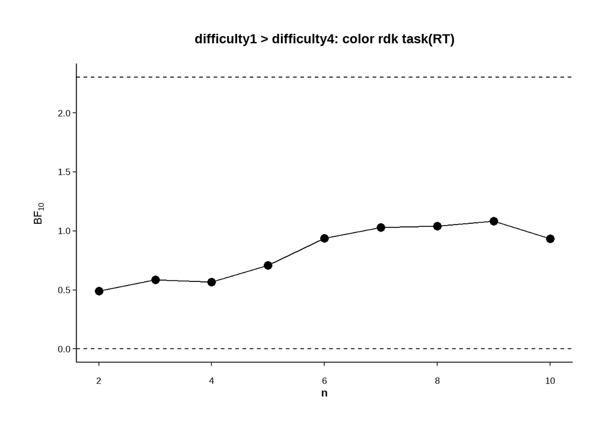

```r
plot_bfs_1vs4 <-
  plot_ttest(bfs_int_diff_cr_rt, '1 vs 4', 'difficulty1 > difficulty4: color rdk task(RT)')
plot_bfs_1vs4
```

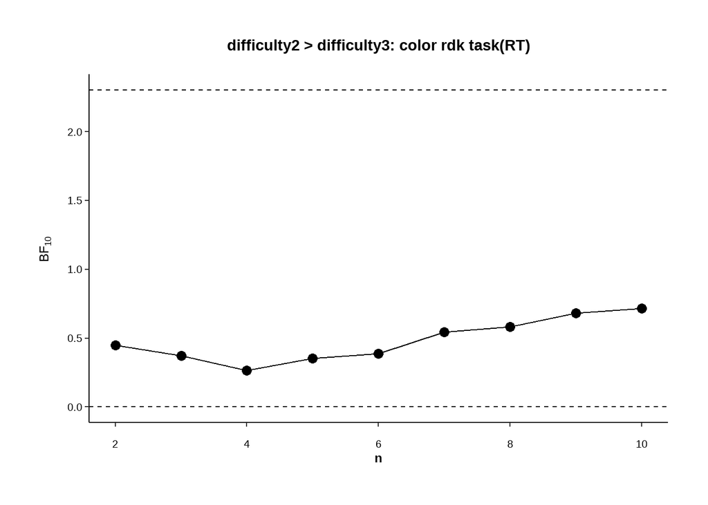

```r
plot_bfs_2vs3 <-
  plot_ttest(bfs_int_diff_cr_rt, '2 vs 3', 'difficulty2 > difficulty3: color rdk task(RT)')
plot_bfs_2vs3
```

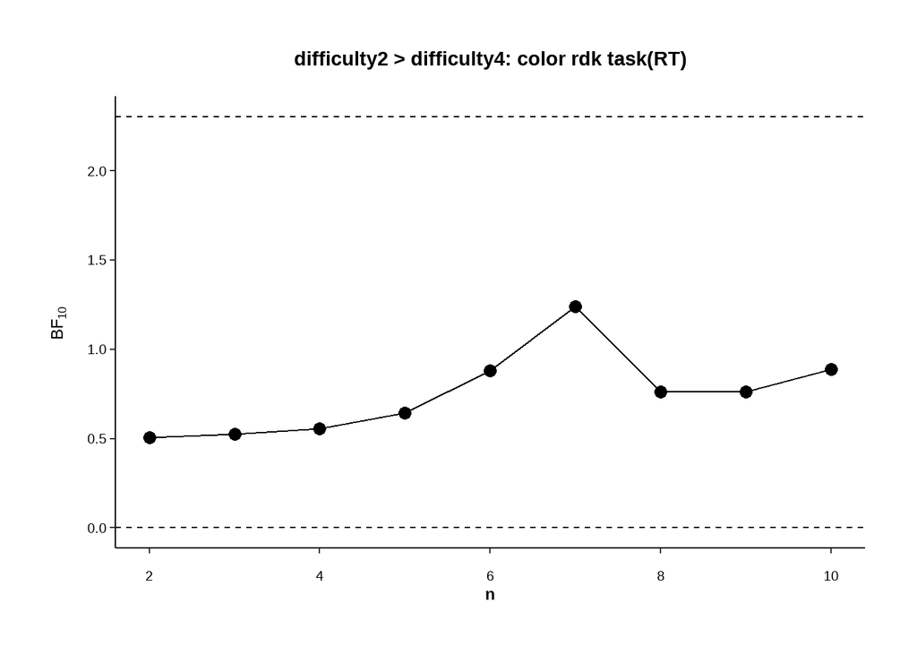

```r
plot_bfs_2vs4 <-
  plot_ttest(bfs_int_diff_cr_rt, '2 vs 4', 'difficulty2 > difficulty4: color rdk task(RT)')
plot_bfs_2vs4
```

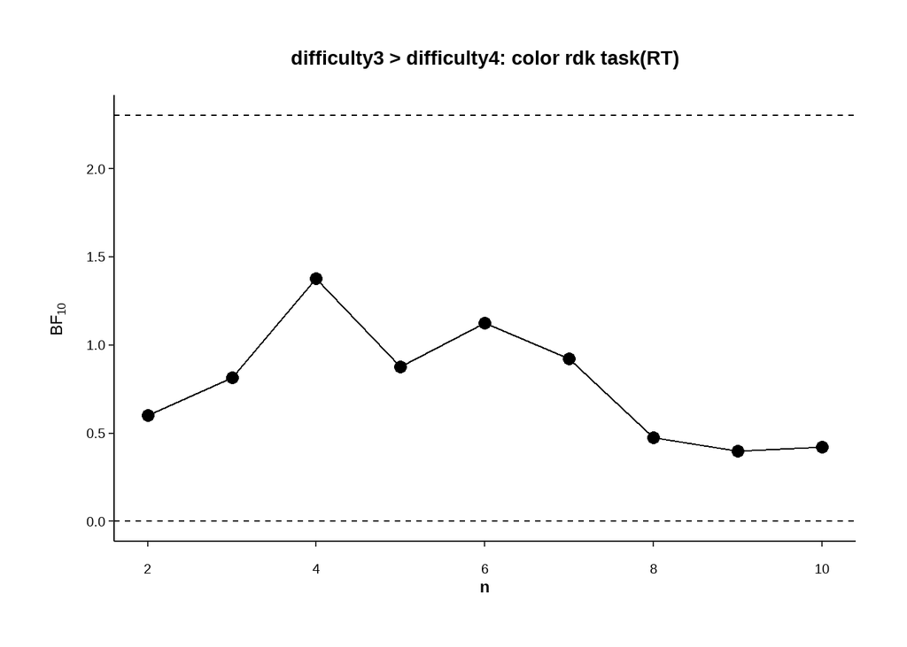

```r
plot_bfs_3vs4 <-
  plot_ttest(bfs_int_diff_cr_rt, '3 vs 4', 'difficulty3 > difficulty4: color rdk task(RT)')
plot_bfs_3vs4
```

**查看数据的变化趋势**

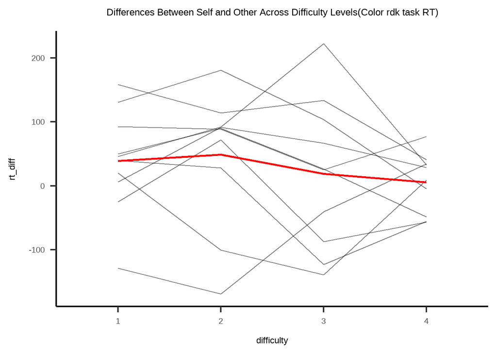

```r
ggplot(df_color_diff_rdk_long, aes(x = difficulty, y = rt_diff, group = subj_idx)) +
  geom_line(alpha = 0.5) +
  stat_summary(aes(group = 1), fun = mean, geom = "line", color = "red", size = 1) + labs(title = "Differences Between Self and Other Across Difficulty Levels(Color rdk task RT)") +
  papaja::theme_apa(base_size = 18,# base_family = "Times"
                    )
```

#### 0.3.2.3 任务间比较

##### 0.3.2.3.1 ACC

```r
bfs_task_diff_acc <- bf_aov(data_color_diff, 'acc_diff_so', 'part')
```

[output not shown]

```
## # A tibble: 10 × 3
##    bfs_a bfs_diff bfs_int
##    <dbl>    <dbl>   <dbl>
##  1 1        1       1
##  2 0.426    0.487   0.261
##  3 0.443    0.517   0.247
##  4 0.411    0.495   0.259
##  5 0.427    0.482   0.262
##  6 0.434    0.507   0.249
##  7 0.446    0.506   0.244
##  8 0.439    0.499   0.249
##  9 0.430    0.486   0.254
## 10 0.430    0.491   0.268
```

```r
bfs_task_diff_acc
```

```
## # A tibble: 10 × 3
##    bfs_a bfs_diff bfs_int
##    <dbl>    <dbl>   <dbl>
##  1 1        1       1
##  2 0.426    0.487   0.261
##  3 0.443    0.517   0.247
##  4 0.411    0.495   0.259
##  5 0.427    0.482   0.262
##  6 0.434    0.507   0.249
##  7 0.446    0.506   0.244
##  8 0.439    0.499   0.249
##  9 0.430    0.486   0.254
## 10 0.430    0.491   0.268
```

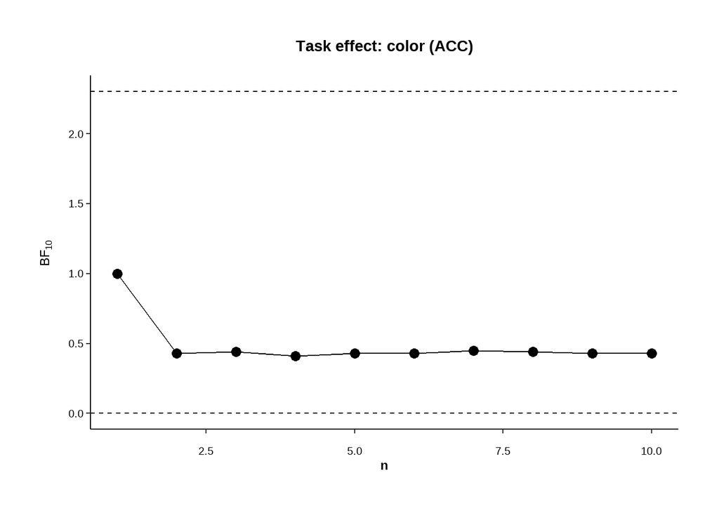

```r
plot_bfs_task <- plot_aov(bfs_task_diff_acc , 'bfs_a', 'Task effect: color (ACC)')
plot_bfs_task
```

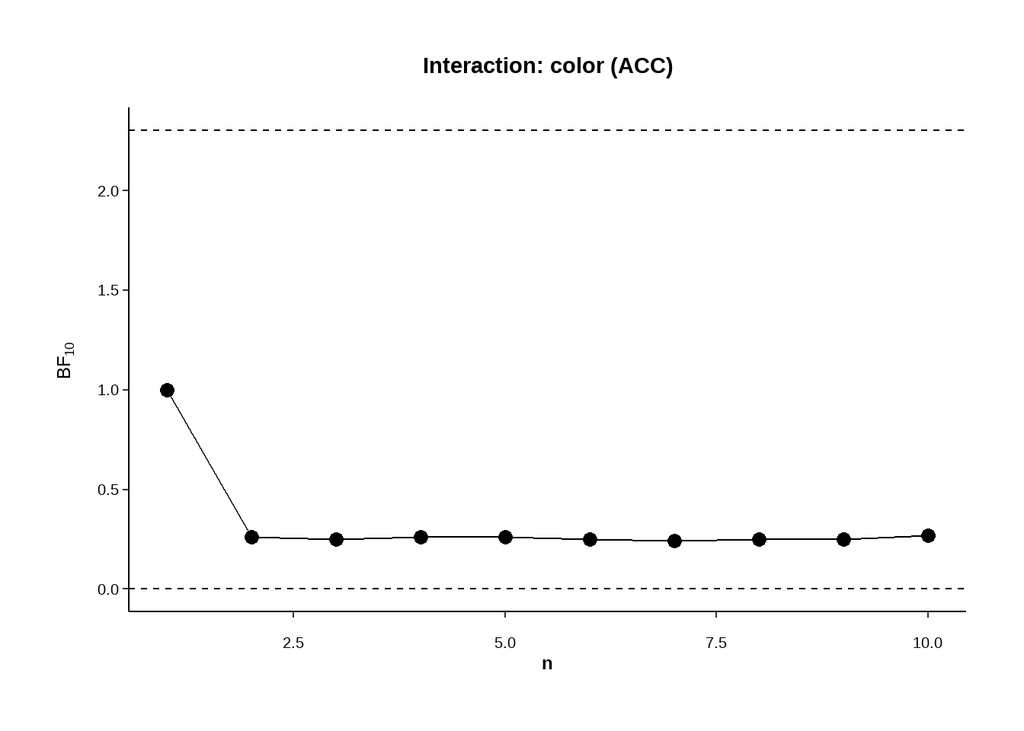

```r
plot_bfs_task_int <- plot_aov(bfs_task_diff_acc , 'bfs_int', 'Interaction: color (ACC)')
plot_bfs_task_int
```

##### 0.3.2.3.2 RT

```r
bfs_task_diff_rt <- bf_aov(data_color_diff, 'rt_diff_os', 'part')
```

[output not shown]

```
## # A tibble: 10 × 3
##    bfs_a bfs_diff bfs_int
##    <dbl>    <dbl>   <dbl>
##  1  1       1       1
##  2  1.14    0.219   0.163
##  3  1.14    0.219   0.160
##  4  1.13    0.223   0.163
##  5  1.15    0.212   0.165
##  6  1.12    0.214   0.163
##  7  1.18    0.225   0.157
##  8  1.15    0.218   0.163
##  9  1.18    0.224   0.157
## 10  1.17    0.226   0.167
```

```r
bfs_task_diff_rt
```

```
## # A tibble: 10 × 3
##    bfs_a bfs_diff bfs_int
##    <dbl>    <dbl>   <dbl>
##  1  1       1       1
##  2  1.14    0.219   0.163
##  3  1.14    0.219   0.160
##  4  1.13    0.223   0.163
##  5  1.15    0.212   0.165
##  6  1.12    0.214   0.163
##  7  1.18    0.225   0.157
##  8  1.15    0.218   0.163
##  9  1.18    0.224   0.157
## 10  1.17    0.226   0.167
```

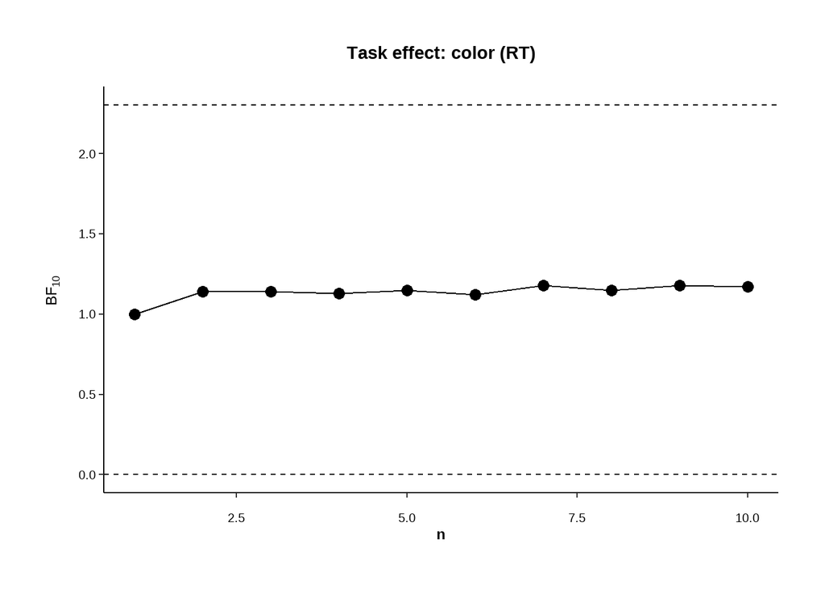

```r
plot_bfs_task <- plot_aov(bfs_task_diff_rt , 'bfs_a', 'Task effect: color (RT)')
plot_bfs_task
```

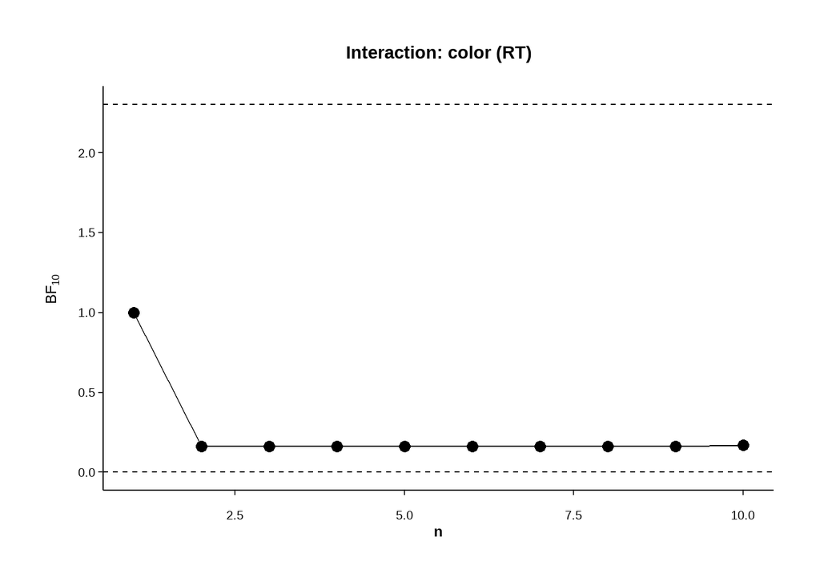

```r
plot_bfs_task_int <- plot_aov(bfs_task_diff_rt , 'bfs_int', 'Interaction: color (RT)')
plot_bfs_task_int
```

**End**